# Determinantes económicos del tipo de cambio en México: un modelo VAR para el período 2004-2020

García Giovanny, Hernández Rommel, Mendoza Paola

16/12/2021

# **1. IntroducciÃ³n.**

## **Motivación y revisión teórica.**

En un contexto de una globalización latente e integración entre las distintas economías del globo, el tipo de cambio ocupa un papel fundamental para la política económica de cualquier país, al ser una variable presente en las finanzas internacionales, el comercio exterior y en la economía en general, por lo que jugará a favor o en contra de la estabilidad al interior de una economía - sobre todo si es una economía tomadora de precios-. El tipo de cambio no es inocuo, de este puede depender la fortaleza y competitividad de una economía o también puede ser un medio importante para la transmisión y propagación de una crisis financiera. Por tal importancia, resulta valioso entender la interrelación y la forma de interacción que existe entre el tipo de cambio y otras variables relevantes de la economía.

Aún al día de hoy los determinantes del tipo de cambio es un tema que sigue debatiéndose en la academia, muchos investigadores han aportado su opinión sobre cuáles son los principales determinantes del tipo de cambio: Taylor (1995) citado en Navarro y Santos (2007), llama fundamentales a todas esas variables derivadas de los cuatro modelos cambiarios modernos principales: el modelo monetarista, monetarista de rigideces de precios, equilibrio general y el de balance de portafolio, para Sizakmary y Mathur (1997) citado en Navarro y Santos (2007) los determinantes son: gasto público, oferta monetaria, inflación, comercio exterior, tipos de interés y stock de precios, mientras que Calderón y Douglas (2003) citado en Navarro y Santos (2007) se centran en el comercio internacional, señalando los determinantes siguientes: términos de comercio, producción, apertura del país al comercio internacional, aranceles y gasto del gobierno. Sin embargo la conceptualización de los determinantes del tipo de cambio de Morales e Higuera (2007) el cual, además de la clasificación de variables determinantes del tipo de cambio entre económicas-financieras, hace una bifurcación entre los determinantes por su temporalidad de corto plazo y largo plazo, es una alternativa para tener un mayor entendimiento y acercamiento al problema del entendimiento de los determinantes de la paridad cambiaria.

Estos determinantes de corto plazo del tipo de cambio suelen incluir:

**a) Condiciones monetarias de oferta y demanda:** Si hay una mayor cantidad de oferta de pesos la moneda se apreciará pero en el largo plazo se depreciará. Lo mismo ocurre con los dólares, si hay una mayor cantidad de dólares en la economía esta se aprecia.

**b) El riesgo:** El riesgo es un determinante fundamental, Navarro y Santos (2007) lo miran desde dos perspectivas, por un lado, mencionan que existe el riesgo en el que empresas e instituciones financieras incurren y el riesgo global. El primero se refleja en moneda extranjera, si existe una depreciación de la moneda, sus pasivos que se tienen en moneda extranjera se deprecian. El riesgo global, en el cual los agentes económicos por medio del âmercado de valoresâ hacen estudios de mercado para inferir y al haber un panorama general riesgoso, los extranjeros que mantienen sus activos en el país se llevan sus recursos, de modo que hay presiones para depreciar la moneda.

**c) Expectativas del mercado:** Es uno de los determinantes más importantes, sí el rendimiento que se espera en la moneda nacional es alto, su demanda será mayor, por lo cual existirá una apreciación, es decir, si la tasa de interés nacional sube y lo demás permanece constante, entonces la ganancia de los activos locales sube a comparación de los extranjeros, así es como la moneda se aprecia.

Por otra parte, hay que tomar en cuenta que existe tanto la tasa de interés nominal y la tasa de interés real. Cuando la tasa de interés nominal contiene inflación esperada permaneciendo sin cambio y la tasa de interés real tiene un incremento como consecuencia el tipo de cambio se aprecia, por el contrario si hay una mayor inflación esperada incrementándose la tasa de interés nominal, el rendimiento disminuirá y la moneda se depreciará. Para estimar las expectativas estas se obtienen mediante un promedio de cuatro años de tasas de inflación del IPC. Este procedimiento se realiza después de un cálculo de tasas de interés real después de impuestos. Cuando la tasa de interés interna no está alineada a la tasa de interés externa repercutirá en la cuenta corriente, (Wijnbergen, 1990).

Para el largo plazo, algunos determinantes del tipo de cambio:

**a) El nivel de precios:** La diferencia de precios entre la economía interna y la economía externa provoca volatilidad cambiaria, si el nivel de precios de México es mayor al nivel de precios de Estados Unidos, la moneda se depreciará, sin embargo; si el nivel de precios de Estados Unidos es mayor al nivel de precios de México, la moneda se apreciará.

**b) Cuenta corriente:** Cuando existe un déficit externo en la cuenta corriente, significa que el gasto agregado interno sobrepasa al ingreso agregado, por otro lado no revela nada de que la demanda agregada ya sea interna o externa solo en bienes nacionales sobrepase la oferta agregada de bienes internos al tipo de cambio real, (Wijnbergen, 1990), no obstante existe una relación cuando se involucra la tasa de interés, ya que si esta se eleva o se reduce, disminuye o aumenta consecutivamente los bienes de consumo y de inversión.

**c) Productividad:** A largo plazo la productividad repercute significativamente debido a que se ajusta muy lentamente. Al haber un aumento en la productividad esto se traduce en mayores exportaciones, lo cual atrae mayor moneda extranjera, por ende presiona el tipo de cambio a bajar.

En la realidad el tipo de cambio está mucho más influenciado por los factores de corto plazo, que los de largo plazo, esto al menos para la economía mexicana sobre la cual se puede hacer una comprobación empírica de esto. Además de los principales determinantes de corto y largo plazo mencionados, podemos encontrar también otros como: movimientos de los flujos de capitales internacionales, la volatilidad en el índice de precios y cotizaciones de la Bolsa de Valores, los incrementos de las tasas de interés extranjeras, el precio del petróleo, el saldo de las reservas internacionales, y los eventos económicos, políticos y sociales, además, también el manejo del gobierno puede inducir en forma indirecta el comportamiento del tipo de cambio por medio de la política monetaria y fiscal. Y si adicionalmente suceden eventos no previstos como crisis repentinas en algún país o región se complica definir los determinantes de la paridad de una moneda. Además a los determinantes de largo plazo podemos añadir también: tasas de interés, la oferta monetaria, la inversión, los ciclos económicos.

La explicación de la existencia de una gran cantidad de determinantes y factores que buscan explicar el tipo de cambio es respuesta y en parte por la igual amplia diversidad de sistemas cambiarios que han existido, no sólo en México, sino en todo el mundo y en respuesta a ello la diversidad de teorías que se han adaptado a cada uno estos para ser explicados y utilizados acorde a las necesidades del momento. A la actualidad la discusión parece haber quedado en un callejón sin salida, algunas de las variables y factores que hemos mencionado que influyen en el tipo de cambio en el corto plazo no están propiamente considerados en la teoría clásica de la Paridad del Poder de Compra o modelos empíricos derivados directamente de aquella teoría o de la combinación de ellas para explicar la determinación del tipo de cambio, esto para el caso mexicano, por tanto y en este sentido, resultará menester de este trabajo estimar un modelo de Vectores Autorregresivos (VAR) que sea capaz - con sus limitaciones teóricas - de describir el comportamiento y la interrelación que existe entre variables que determinan el tipo de cambio fix en el corto plazo para la economía mexicana.

### *Otros trabajos*.

Los estudios que se han publicado han centrado su atención en la evaluación del comportamiento del tipo de cambio nominal y real, mas no así en las variables que lo determinan. Engel (2000) y Mendoza (2000), por ejemplo, identifican los factores que han influido en la variación del tipo de cambio real.

Werner (1997a) realizó un estudio sobre el comportamiento del tipo de cambio en México en el periodo de 1995-1996, durante el cual se mantenía un esquema cambiario de flotación libre, estudió el efecto de las tasas de interés nacionales e internacionales sobre el tipo de cambio y su volatilidad, sin embargo no se identifican las variables determinantes influyentes en el tipo de cambio. Werner y Bazdresch (2002) desarrollaron un modelo monetario de determinación del tipo de cambio de determinación del tipo de cambio para explicar los movimientos diarios en el valor del peso respecto al dólar, sin identificar las variables que han influido en estos movimientos del tipo de cambio. Alejandro Macías (2003) realiza un análisis teórico del modelo de la Paridad del Poder de Compra en el periodo 1982-2002 para México, y Ramón Castillo y Jorge Herrera (2005) prueban los modelos monetarios tradicionales básicos del tipo de cambio. A la vez, Josefina León León (2008), da a conocer los factores económicos, políticos y sociales que influyeron en el comportamiento del tipo de cambio a finales de 1994.

La importancia de estos estudios es que sus resultados ayudan a comprender el comportamiento del tipo de cambio peso-dólar, pero no así las variables que determinan su evolución. En regímenes previos al de libre flotación, como el fijo, de vínculo móvil y múltiple, los determinantes del tipo cambiario eran más o menos conocidos. Sin embargo, con la adopción del régimen de flotación libre, los estudios no han sido determinantes, incluso se ha llegado a pensar que el tipo de cambio dentro de este régimen es producto de un proceso gobernado por el azar.

Sin embargo, utilizando como una inspiración los modelos de determinación del tipo de cambio, además de incluir el precio de petróleo como una variable teórica, histórica y además comprobable empíricamente muestra una correlación importante con el comportamiento del tipo de cambio para la economía mexicana. Se estimó un VAR a corto plazo, para dar cuenta de las variables económico-financieras que influyen en el comportamiento del tipo de cambio en el corto plazo.

# **2. SelecciÃ³n de Variables**

### *Selección de metodología*

Se ha decidido utilizar una metodología de Vectores Autorregresivos, dado que únicamente se necesita especificar las variables que intervienen y el número de rezagos adecuados, que es ideal para el modelo que se pretende especificar, modelo que recoja de la mejor forma la evolución de un sistema económico sin establecer demasiadas restricciones.

Para la selección de variables se han seguido las sugeridas por Ito Takatoshi et al. (2005) y por Timotea Ma. de la Paz Guzmán Plata (2006), las cuales son: precio de petróleo (PP), la oferta monetaria medidas a través del M2 (M2), la brecha del producto (bP), la inflación doméstica incorporada a través del Índice Nacional de Precios al Productor (INPP), el tipo de cambio fix (Fix), y adicionalmente a estas variables propuestas, se ha añadido la tasa de interés de corto plazo considerando la de CETES a 28 días (CETES).

La periodicidad de todas las variables es mensual, con observaciones que van desde Enero del 2004 hasta Diciembre del 2020

[output not shown]

##Paquetes y Datos

```r
library(ggplot2)
library(dplyr)
library(readxl)
library(stats)
library(seasonal)
library(seasonalview)
library(shiny)
library(stats)
library(MASS)
library(strucchange)
library(zoo)
library(sandwich)
library(urca)
library(lmtest)
library(vars)
library(tidyr)
library(forecast)
library(mFilter)

#dat <- read_excel("C:/Users/tic12/OneDrive/Escritorio/EconomÃa/Nucleo terminal/EconomÃa cuantitativa/Series de tiempo/BD Sdt.xlsx", sheet = "2004", col_names = TRUE)
dat<-read_excel("C:/Users/Jack/Documents/FACULTAD DE ECONOMÍA/9° semestre/Series de tiempo/Trabajo final/BD SdT.xlsx", sheet = "2004", col_names = TRUE)
head(dat)
```

```
## # A tibble: 6 x 8
##   Fecha                        M2 PETROLEO   FIX CETES  IMAI  INPP CETES100
##   <dttm>                    <dbl>    <dbl> <dbl> <dbl> <dbl> <dbl>    <dbl>
## 1 2004-01-01 00:00:00 2339289329.     31.4  10.9  4.95  91    49.0   0.0495
## 2 2004-02-01 00:00:00 2285732239.     31.3  11.0  5.57  90.9  49.6   0.0557
## 3 2004-03-01 00:00:00 2312217167.     33.7  11.0  6.28  92.3  50.2   0.0628
## 4 2004-04-01 00:00:00 2306755673.     33.7  11.3  5.98  92.3  50.7   0.0598
## 5 2004-05-01 00:00:00 2291715363.     37.6  11.5  6.59  92.1  51.0   0.0659
## 6 2004-06-01 00:00:00 2336357856.     35.5  11.4  6.57  92.3  51.3   0.0657
```

##Gráficas, desestacionalización y diferencias.

```r
M2 <- ts(dat$M2,
        start = c(2004,1),
         frequency = 12)

pp <- ts(dat$PETROLEO,
         start = c(2004,1),
         frequency = 12)

FIX <- ts(dat$FIX,
         start = c(2004,1),
         frequency = 12)

CETES <- ts(dat$CETES,
         start = c(2004,1),
         frequency = 12)

IMAI <- ts(dat$IMAI,
            start = c(2004,1),
            frequency = 12)

INPP <- ts(dat$INPP,
           start = c(2004,1),
           frequency = 12)

#Desestacionalizar las series y crear una nueva variable a partir de ello.
M2_Seas <- seas(M2)
M2D <- final(M2_Seas)

pp_Seas <- seas(pp)
```

```
## Model used in SEATS is different: (0 1 1)
```

```r
ppD <- final(pp_Seas)

FIX_Seas <- seas(FIX)
FIXD <- final(FIX_Seas)

CETES_Seas <- seas(CETES)
CETESD <- final(CETES_Seas)

INPP_Seas <- seas(INPP)
INPPD <- final(INPP_Seas)

IMAI_Seas<-seas(IMAI)
```

```
## Model used in SEATS is different: (1 1 2)(1 0 0)
```

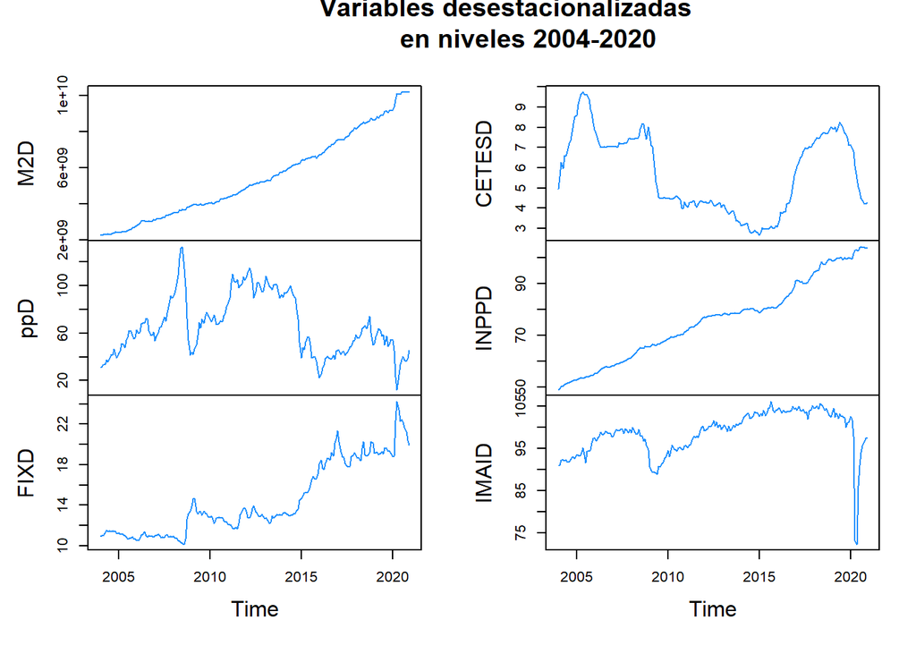

```r
IMAID<-final(IMAI_Seas)

plot(cbind(M2D, ppD, FIXD, CETESD,INPPD,IMAID), main="Variables desestacionalizadas
     en niveles 2004-2020", col="dodgerblue")
```

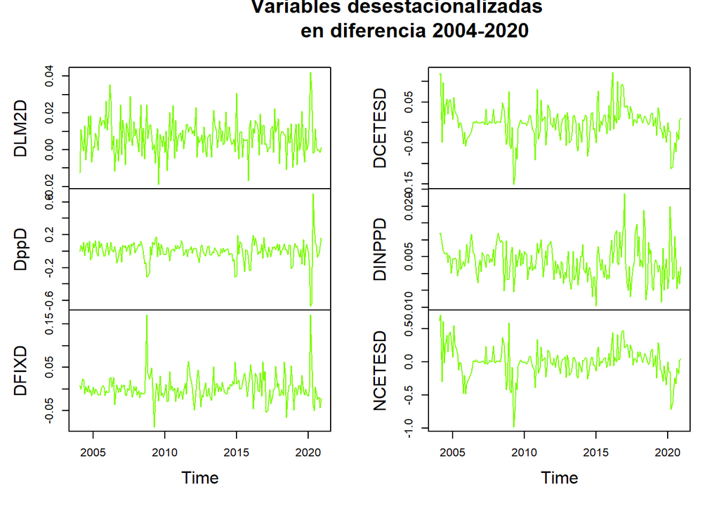

```r
#Obtener diferencias o diferencias logarÃtmicas
DifCETES<- ts(as.numeric(CETESD) - lag(as.numeric(CETESD), k = 1),
             start = c(2004,1),frequency = 12)

DIMAI<- ts(log(as.numeric(IMAI)) - lag(log(as.numeric(IMAI)), k = 1),
                 start = c(2004,1),frequency = 12)

DLM2D <- ts(log(as.numeric(M2D)) - lag(log(as.numeric(M2D)), k = 1),
             start = c(2004,1),frequency = 12)

DppD<- ts(log(as.numeric(ppD)) - lag(log(as.numeric(ppD)), k = 1),
          start = c(2004,1),frequency = 12)

DFIXD<- ts(log(as.numeric(FIXD)) - lag(log(as.numeric(FIXD)), k = 1),
           start = c(2004,1),frequency = 12)

DCETESD<- ts(log(as.numeric(CETESD)) - lag(log(as.numeric(CETESD)), k = 1),
             start = c(2004,1),frequency = 12)

DINPPD<- ts(log(as.numeric(INPPD)) - lag(log(as.numeric(INPPD)), k = 1),
               start = c(2004,1),frequency = 12)

NCETESD<-ts(as.numeric(CETESD) - lag(as.numeric(CETESD), k = 1),
            start = c(2004,1),frequency = 12)

plot(cbind(DLM2D,DppD,DFIXD,DCETESD,DINPPD,NCETESD), main="Variables desestacionalizadas
     en diferencia 2004-2020", col="lawngreen")
```

##Pruebas de Estacionalidad

```r
Dato<-data.frame(cbind(M2D,ppD,FIXD,CETESD,INPPD,IMAID))
Dato<-na.omit(Dato)
head(Dato)
```

```
##          M2D   ppD    FIXD CETESD    INPPD IMAID
## 1 2303394290 31.37 10.9151 4.9525 49.03742  91.0
## 2 2274700606 31.33 11.0142 5.5700 49.62254  90.9
## 3 2299985257 33.67 11.0094 6.2775 50.22059  92.3
## 4 2304643791 33.71 11.2751 5.9800 50.67194  92.3
## 5 2303274470 37.56 11.5124 6.5925 51.02616  92.1
## 6 2333645185 35.54 11.3894 6.5700 51.34040  92.3
```

```r
#Serie con diferencias/diferencias logarÃtmicas
DatosD<-data.frame(cbind(DLM2D,DppD,DFIXD,DifCETES,DINPPD,DIMAI))
DatosD<-na.omit(DatosD)
head(DatosD)
```

```
##          DLM2D         DppD        DFIXD DifCETES      DINPPD        DIMAI
## 2 -0.012535371 -0.001275917  0.009038198   0.6175 0.011861575 -0.001099505
## 3  0.011054271  0.072031128 -0.000435896   0.7075 0.011979763  0.015284140
## 4  0.002023414  0.001187296  0.023847301  -0.2975 0.008947344  0.000000000
## 5 -0.000594334  0.108145125  0.020827961   0.6125 0.006966098 -0.002169198
## 6  0.013099709 -0.055280832 -0.010741617  -0.0225 0.006139573  0.002169198
## 7 -0.005543843  0.064028402  0.006493700   0.2400 0.005856851 -0.005431844
```

```r
##PRUEBAS RAÃCES UNITARIAS

#DICKY FULLER

#Oferta monetaria
#En niveles
summary(ur.df(Dato[,1], type="trend", lags=0)) # -3.43<-0.73 Ho: No estacionaria
```

```
##
## ###############################################
## # Augmented Dickey-Fuller Test Unit Root Test #
## ###############################################
##
## Test regression trend
##
##
## Call:
## lm(formula = z.diff ~ z.lag.1 + 1 + tt)
##
## Residuals:
##        Min         1Q     Median         3Q        Max
## -161032995  -29421162   -3274982   24242042  348096178
##
## Coefficients:
##               Estimate Std. Error t value Pr(>|t|)
## (Intercept)  2.811e+07  1.876e+07   1.498    0.136
## z.lag.1     -7.957e-03  1.084e-02  -0.734    0.464
## tt           5.311e+05  4.187e+05   1.268    0.206
##
## Residual standard error: 57270000 on 200 degrees of freedom
## Multiple R-squared:  0.05466,    Adjusted R-squared:  0.0452
## F-statistic: 5.782 on 2 and 200 DF,  p-value: 0.003622
##
##
## Value of test-statistic is: -0.7343 35.079 5.7816
##
## Critical values for test statistics:
##       1pct  5pct 10pct
## tau3 -3.99 -3.43 -3.13
## phi2  6.22  4.75  4.07
## phi3  8.43  6.49  5.47
```

```r
summary(ur.df(Dato[,1], type="drift", lags=0)) # -2.88<3.15  Ho: No estacionaria
```

```
##
## ###############################################
## # Augmented Dickey-Fuller Test Unit Root Test #
## ###############################################
##
## Test regression drift
##
##
## Call:
## lm(formula = z.diff ~ z.lag.1 + 1)
##
## Residuals:
##        Min         1Q     Median         3Q        Max
## -156219412  -29751136    -508829   23502411  343785119
##
## Coefficients:
##              Estimate Std. Error t value Pr(>|t|)
## (Intercept) 8.376e+06  1.049e+07   0.798  0.42570
## z.lag.1     5.601e-03  1.778e-03   3.150  0.00188 **
## ---
## Signif. codes:  0 '***' 0.001 '**' 0.01 '*' 0.05 '.' 0.1 ' ' 1
##
## Residual standard error: 57360000 on 201 degrees of freedom
## Multiple R-squared:  0.04705,    Adjusted R-squared:  0.04231
## F-statistic: 9.925 on 1 and 201 DF,  p-value: 0.00188
##
##
## Value of test-statistic is: 3.1503 51.658
##
## Critical values for test statistics:
##       1pct  5pct 10pct
## tau2 -3.46 -2.88 -2.57
## phi1  6.52  4.63  3.81
```

```r
summary(ur.df(Dato[,1], type="none", lags=0))  # -1.95<10.14 Ho: No estacionaria
```

```
##
## ###############################################
## # Augmented Dickey-Fuller Test Unit Root Test #
## ###############################################
##
## Test regression none
##
##
## Call:
## lm(formula = z.diff ~ z.lag.1 - 1)
##
## Residuals:
##        Min         1Q     Median         3Q        Max
## -156574646  -28316917    2042232   26157779  339878686
##
## Coefficients:
##          Estimate Std. Error t value Pr(>|t|)
## z.lag.1 0.0069114  0.0006815   10.14   <2e-16 ***
## ---
## Signif. codes:  0 '***' 0.001 '**' 0.01 '*' 0.05 '.' 0.1 ' ' 1
##
## Residual standard error: 57310000 on 202 degrees of freedom
## Multiple R-squared:  0.3374, Adjusted R-squared:  0.3341
## F-statistic: 102.9 on 1 and 202 DF,  p-value: < 2.2e-16
##
##
## Value of test-statistic is: 10.1422
##
## Critical values for test statistics:
##       1pct  5pct 10pct
## tau1 -2.58 -1.95 -1.62
```

```r
#En diferencias
summary(ur.df(DatosD[,1], type="trend", lags=0)) # -3.43>-14.15 Ha: Es estacionaria
```

```
##
## ###############################################
## # Augmented Dickey-Fuller Test Unit Root Test #
## ###############################################
##
## Test regression trend
##
##
## Call:
## lm(formula = z.diff ~ z.lag.1 + 1 + tt)
##
## Residuals:
##       Min        1Q    Median        3Q       Max
## -0.026742 -0.006294 -0.000193  0.005178  0.035843
##
## Coefficients:
##               Estimate Std. Error t value Pr(>|t|)
## (Intercept)  8.584e-03  1.429e-03   6.005 8.94e-09 ***
## z.lag.1     -9.916e-01  7.005e-02 -14.156  < 2e-16 ***
## tt          -1.199e-05  1.120e-05  -1.071    0.286
## ---
## Signif. codes:  0 '***' 0.001 '**' 0.01 '*' 0.05 '.' 0.1 ' ' 1
##
## Residual standard error: 0.009269 on 199 degrees of freedom
## Multiple R-squared:  0.5019, Adjusted R-squared:  0.4969
## F-statistic: 100.2 on 2 and 199 DF,  p-value: < 2.2e-16
##
##
## Value of test-statistic is: -14.1555 66.8364 100.2493
##
## Critical values for test statistics:
##       1pct  5pct 10pct
## tau3 -3.99 -3.43 -3.13
## phi2  6.22  4.75  4.07
## phi3  8.43  6.49  5.47
```

```r
summary(ur.df(DatosD[,1], type="drift", lags=0)) # -2.88>-14.11 Ha: Es estacionaria
```

```
##
## ###############################################
## # Augmented Dickey-Fuller Test Unit Root Test #
## ###############################################
##
## Test regression drift
##
##
## Call:
## lm(formula = z.diff ~ z.lag.1 + 1)
##
## Residuals:
##       Min        1Q    Median        3Q       Max
## -0.026333 -0.006244  0.000115  0.005130  0.034703
##
## Coefficients:
##               Estimate Std. Error t value Pr(>|t|)
## (Intercept)  0.0073385  0.0008313   8.828 5.38e-16 ***
## z.lag.1     -0.9877318  0.0699822 -14.114  < 2e-16 ***
## ---
## Signif. codes:  0 '***' 0.001 '**' 0.01 '*' 0.05 '.' 0.1 ' ' 1
##
## Residual standard error: 0.009272 on 200 degrees of freedom
## Multiple R-squared:  0.499,  Adjusted R-squared:  0.4965
## F-statistic: 199.2 on 1 and 200 DF,  p-value: < 2.2e-16
##
##
## Value of test-statistic is: -14.114 99.6084
##
## Critical values for test statistics:
##       1pct  5pct 10pct
## tau2 -3.46 -2.88 -2.57
## phi1  6.52  4.63  3.81
```

```r
summary(ur.df(DatosD[,1], type="none", lags=0))  # -1.95>-9.37 Ha: Es estacionaria
```

```
##
## ###############################################
## # Augmented Dickey-Fuller Test Unit Root Test #
## ###############################################
##
## Test regression none
##
##
## Call:
## lm(formula = z.diff ~ z.lag.1 - 1)
##
## Residuals:
##       Min        1Q    Median        3Q       Max
## -0.023466 -0.002111  0.004914  0.010800  0.034917
##
## Coefficients:
##         Estimate Std. Error t value Pr(>|t|)
## z.lag.1 -0.60485    0.06458  -9.365   <2e-16 ***
## ---
## Signif. codes:  0 '***' 0.001 '**' 0.01 '*' 0.05 '.' 0.1 ' ' 1
##
## Residual standard error: 0.0109 on 201 degrees of freedom
## Multiple R-squared:  0.3038, Adjusted R-squared:  0.3003
## F-statistic: 87.71 on 1 and 201 DF,  p-value: < 2.2e-16
##
##
## Value of test-statistic is: -9.3654
##
## Critical values for test statistics:
##       1pct  5pct 10pct
## tau1 -2.58 -1.95 -1.62
```

```r
#Precio del petrÃ³leo
#En niveles
summary(ur.df(Dato[,2], type="trend", lags=0)) # -3.43<-2.19 Ho: No estacionaria
```

```
##
## ###############################################
## # Augmented Dickey-Fuller Test Unit Root Test #
## ###############################################
##
## Test regression trend
##
##
## Call:
## lm(formula = z.diff ~ z.lag.1 + 1 + tt)
##
## Residuals:
##      Min       1Q   Median       3Q      Max
## -26.2725  -2.7830   0.9426   3.7814  14.8593
##
## Coefficients:
##              Estimate Std. Error t value Pr(>|t|)
## (Intercept)  3.748854   1.557432   2.407   0.0170 *
## z.lag.1     -0.038213   0.017424  -2.193   0.0295 *
## tt          -0.011194   0.007438  -1.505   0.1339
## ---
## Signif. codes:  0 '***' 0.001 '**' 0.01 '*' 0.05 '.' 0.1 ' ' 1
##
## Residual standard error: 6.101 on 200 degrees of freedom
## Multiple R-squared:  0.02937,    Adjusted R-squared:  0.01966
## F-statistic: 3.026 on 2 and 200 DF,  p-value: 0.05074
##
##
## Value of test-statistic is: -2.1931 2.0261 3.0259
##
## Critical values for test statistics:
##       1pct  5pct 10pct
## tau3 -3.99 -3.43 -3.13
## phi2  6.22  4.75  4.07
## phi3  8.43  6.49  5.47
```

```r
summary(ur.df(Dato[,2], type="drift", lags=0)) # -2.88<-1.94  Ho: No estacionaria
```

```
##
## ###############################################
## # Augmented Dickey-Fuller Test Unit Root Test #
## ###############################################
##
## Test regression drift
##
##
## Call:
## lm(formula = z.diff ~ z.lag.1 + 1)
##
## Residuals:
##     Min      1Q  Median      3Q     Max
## -25.932  -2.896   0.937   3.776  15.211
##
## Coefficients:
##             Estimate Std. Error t value Pr(>|t|)
## (Intercept)  2.28162    1.21832   1.873   0.0626 .
## z.lag.1     -0.03331    0.01717  -1.940   0.0538 .
## ---
## Signif. codes:  0 '***' 0.001 '**' 0.01 '*' 0.05 '.' 0.1 ' ' 1
##
## Residual standard error: 6.12 on 201 degrees of freedom
## Multiple R-squared:  0.01838,    Adjusted R-squared:  0.0135
## F-statistic: 3.763 on 1 and 201 DF,  p-value: 0.05379
##
##
## Value of test-statistic is: -1.9399 1.8949
##
## Critical values for test statistics:
##       1pct  5pct 10pct
## tau2 -3.46 -2.88 -2.57
## phi1  6.52  4.63  3.81
```

```r
summary(ur.df(Dato[,2], type="none", lags=0))  # -1.95<-0.52 Ho: No estacionaria
```

```
##
## ###############################################
## # Augmented Dickey-Fuller Test Unit Root Test #
## ###############################################
##
## Test regression none
##
##
## Call:
## lm(formula = z.diff ~ z.lag.1 - 1)
##
## Residuals:
##     Min      1Q  Median      3Q     Max
## -26.649  -2.555   1.422   4.262  14.220
##
## Coefficients:
##          Estimate Std. Error t value Pr(>|t|)
## z.lag.1 -0.003219   0.006091  -0.528    0.598
##
## Residual standard error: 6.158 on 202 degrees of freedom
## Multiple R-squared:  0.00138,    Adjusted R-squared:  -0.003563
## F-statistic: 0.2792 on 1 and 202 DF,  p-value: 0.5978
##
##
## Value of test-statistic is: -0.5284
##
## Critical values for test statistics:
##       1pct  5pct 10pct
## tau1 -2.58 -1.95 -1.62
```

```r
#En diferencias
summary(ur.df(DatosD[,2], type="trend", lags=0)) # -3.43>-10.81 Ha: Es estacionaria
```

```
##
## ###############################################
## # Augmented Dickey-Fuller Test Unit Root Test #
## ###############################################
##
## Test regression trend
##
##
## Call:
## lm(formula = z.diff ~ z.lag.1 + 1 + tt)
##
## Residuals:
##      Min       1Q   Median       3Q      Max
## -0.61367 -0.05127  0.01250  0.05987  0.87674
##
## Coefficients:
##               Estimate Std. Error t value Pr(>|t|)
## (Intercept)  0.0119421  0.0173045    0.69    0.491
## z.lag.1     -0.7450987  0.0689058  -10.81   <2e-16 ***
## tt          -0.0001020  0.0001479   -0.69    0.491
## ---
## Signif. codes:  0 '***' 0.001 '**' 0.01 '*' 0.05 '.' 0.1 ' ' 1
##
## Residual standard error: 0.1222 on 199 degrees of freedom
## Multiple R-squared:  0.3702, Adjusted R-squared:  0.3638
## F-statistic: 58.48 on 2 and 199 DF,  p-value: < 2.2e-16
##
##
## Value of test-statistic is: -10.8133 38.9871 58.4762
##
## Critical values for test statistics:
##       1pct  5pct 10pct
## tau3 -3.99 -3.43 -3.13
## phi2  6.22  4.75  4.07
## phi3  8.43  6.49  5.47
```

```r
summary(ur.df(DatosD[,2], type="drift", lags=0)) # -2.88>-10.81 Ha: Es estacionaria
```

```
##
## ###############################################
## # Augmented Dickey-Fuller Test Unit Root Test #
## ###############################################
##
## Test regression drift
##
##
## Call:
## lm(formula = z.diff ~ z.lag.1 + 1)
##
## Residuals:
##      Min       1Q   Median       3Q      Max
## -0.62237 -0.04939  0.01430  0.06072  0.86961
##
## Coefficients:
##              Estimate Std. Error t value Pr(>|t|)
## (Intercept)  0.001584   0.008587   0.184    0.854
## z.lag.1     -0.741376   0.068604 -10.807   <2e-16 ***
## ---
## Signif. codes:  0 '***' 0.001 '**' 0.01 '*' 0.05 '.' 0.1 ' ' 1
##
## Residual standard error: 0.122 on 200 degrees of freedom
## Multiple R-squared:  0.3687, Adjusted R-squared:  0.3655
## F-statistic: 116.8 on 1 and 200 DF,  p-value: < 2.2e-16
##
##
## Value of test-statistic is: -10.8066 58.3958
##
## Critical values for test statistics:
##       1pct  5pct 10pct
## tau2 -3.46 -2.88 -2.57
## phi1  6.52  4.63  3.81
```

```r
summary(ur.df(DatosD[,2], type="none", lags=0))  # -1.95>-10.83 Ha: Es estacionaria
```

```
##
## ###############################################
## # Augmented Dickey-Fuller Test Unit Root Test #
## ###############################################
##
## Test regression none
##
##
## Call:
## lm(formula = z.diff ~ z.lag.1 - 1)
##
## Residuals:
##      Min       1Q   Median       3Q      Max
## -0.62076 -0.04782  0.01588  0.06229  0.87126
##
## Coefficients:
##         Estimate Std. Error t value Pr(>|t|)
## z.lag.1 -0.74127    0.06844  -10.83   <2e-16 ***
## ---
## Signif. codes:  0 '***' 0.001 '**' 0.01 '*' 0.05 '.' 0.1 ' ' 1
##
## Residual standard error: 0.1217 on 201 degrees of freedom
## Multiple R-squared:  0.3686, Adjusted R-squared:  0.3654
## F-statistic: 117.3 on 1 and 201 DF,  p-value: < 2.2e-16
##
##
## Value of test-statistic is: -10.8315
##
## Critical values for test statistics:
##       1pct  5pct 10pct
## tau1 -2.58 -1.95 -1.62
```

```r
#Tipo de cambio
#En niveles
summary(ur.df(Dato[,3], type="trend", lags=0)) # -3.43<-2.56 Ho: No estacionaria
```

```
##
## ###############################################
## # Augmented Dickey-Fuller Test Unit Root Test #
## ###############################################
##
## Test regression trend
##
##
## Call:
## lm(formula = z.diff ~ z.lag.1 + 1 + tt)
##
## Residuals:
##     Min      1Q  Median      3Q     Max
## -1.2481 -0.2465 -0.0595  0.1327  3.4242
##
## Coefficients:
##              Estimate Std. Error t value Pr(>|t|)
## (Intercept)  0.536135   0.214771   2.496   0.0134 *
## z.lag.1     -0.058623   0.022922  -2.558   0.0113 *
## tt           0.003497   0.001391   2.514   0.0127 *
## ---
## Signif. codes:  0 '***' 0.001 '**' 0.01 '*' 0.05 '.' 0.1 ' ' 1
##
## Residual standard error: 0.4934 on 200 degrees of freedom
## Multiple R-squared:  0.03269,    Adjusted R-squared:  0.02302
## F-statistic:  3.38 on 2 and 200 DF,  p-value: 0.03602
##
##
## Value of test-statistic is: -2.5575 2.8055 3.3795
##
## Critical values for test statistics:
##       1pct  5pct 10pct
## tau3 -3.99 -3.43 -3.13
## phi2  6.22  4.75  4.07
## phi3  8.43  6.49  5.47
```

```r
summary(ur.df(Dato[,3], type="drift", lags=0)) # -2.88<-0.65 Ho: No estacionaria
```

```
##
## ###############################################
## # Augmented Dickey-Fuller Test Unit Root Test #
## ###############################################
##
## Test regression drift
##
##
## Call:
## lm(formula = z.diff ~ z.lag.1 + 1)
##
## Residuals:
##     Min      1Q  Median      3Q     Max
## -1.3006 -0.2153 -0.0590  0.1378  3.5178
##
## Coefficients:
##              Estimate Std. Error t value Pr(>|t|)
## (Intercept)  0.138042   0.146982   0.939    0.349
## z.lag.1     -0.006459   0.009864  -0.655    0.513
##
## Residual standard error: 0.4999 on 201 degrees of freedom
## Multiple R-squared:  0.002129,   Adjusted R-squared:  -0.002836
## F-statistic: 0.4288 on 1 and 201 DF,  p-value: 0.5133
##
##
## Value of test-statistic is: -0.6548 1.0217
##
## Critical values for test statistics:
##       1pct  5pct 10pct
## tau2 -3.46 -2.88 -2.57
## phi1  6.52  4.63  3.81
```

```r
summary(ur.df(Dato[,3], type="none", lags=0))  # -1.95<1.078 Ho: No estacionaria
```

```
##
## ###############################################
## # Augmented Dickey-Fuller Test Unit Root Test #
## ###############################################
##
## Test regression none
##
##
## Call:
## lm(formula = z.diff ~ z.lag.1 - 1)
##
## Residuals:
##     Min      1Q  Median      3Q     Max
## -1.3452 -0.1965 -0.0407  0.1341  3.4863
##
## Coefficients:
##         Estimate Std. Error t value Pr(>|t|)
## z.lag.1 0.002537   0.002354   1.078    0.282
##
## Residual standard error: 0.4997 on 202 degrees of freedom
## Multiple R-squared:  0.00572,    Adjusted R-squared:  0.0007977
## F-statistic: 1.162 on 1 and 202 DF,  p-value: 0.2823
##
##
## Value of test-statistic is: 1.078
##
## Critical values for test statistics:
##       1pct  5pct 10pct
## tau1 -2.58 -1.95 -1.62
```

```r
#En diferencias
summary(ur.df(DatosD[,3], type="trend", lags=0)) # -3.43>-10.59 Ha: Es estacionaria
```

```
##
## ###############################################
## # Augmented Dickey-Fuller Test Unit Root Test #
## ###############################################
##
## Test regression trend
##
##
## Call:
## lm(formula = z.diff ~ z.lag.1 + 1 + tt)
##
## Residuals:
##       Min        1Q    Median        3Q       Max
## -0.090858 -0.013633 -0.001198  0.009664  0.168298
##
## Coefficients:
##               Estimate Std. Error t value Pr(>|t|)
## (Intercept)  1.082e-03  4.069e-03   0.266    0.791
## z.lag.1     -7.228e-01  6.823e-02 -10.593   <2e-16 ***
## tt           9.906e-06  3.477e-05   0.285    0.776
## ---
## Signif. codes:  0 '***' 0.001 '**' 0.01 '*' 0.05 '.' 0.1 ' ' 1
##
## Residual standard error: 0.0288 on 199 degrees of freedom
## Multiple R-squared:  0.3606, Adjusted R-squared:  0.3541
## F-statistic: 56.11 on 2 and 199 DF,  p-value: < 2.2e-16
##
##
## Value of test-statistic is: -10.593 37.4072 56.1082
##
## Critical values for test statistics:
##       1pct  5pct 10pct
## tau3 -3.99 -3.43 -3.13
## phi2  6.22  4.75  4.07
## phi3  8.43  6.49  5.47
```

```r
summary(ur.df(DatosD[,3], type="drift", lags=0)) # -2.88>-10.61 Ha: Es estacionaria
```

```
##
## ###############################################
## # Augmented Dickey-Fuller Test Unit Root Test #
## ###############################################
##
## Test regression drift
##
##
## Call:
## lm(formula = z.diff ~ z.lag.1 + 1)
##
## Residuals:
##       Min        1Q    Median        3Q       Max
## -0.091251 -0.014113 -0.001547  0.009534  0.169205
##
## Coefficients:
##              Estimate Std. Error t value Pr(>|t|)
## (Intercept)  0.002085   0.002033   1.026    0.306
## z.lag.1     -0.722092   0.068033 -10.614   <2e-16 ***
## ---
## Signif. codes:  0 '***' 0.001 '**' 0.01 '*' 0.05 '.' 0.1 ' ' 1
##
## Residual standard error: 0.02873 on 200 degrees of freedom
## Multiple R-squared:  0.3603, Adjusted R-squared:  0.3571
## F-statistic: 112.7 on 1 and 200 DF,  p-value: < 2.2e-16
##
##
## Value of test-statistic is: -10.6138 56.329
##
## Critical values for test statistics:
##       1pct  5pct 10pct
## tau2 -3.46 -2.88 -2.57
## phi1  6.52  4.63  3.81
```

```r
summary(ur.df(DatosD[,3], type="none", lags=0))  # -1.95>-10.56 Ha: Es estacionaria
```

```
##
## ###############################################
## # Augmented Dickey-Fuller Test Unit Root Test #
## ###############################################
##
## Test regression none
##
##
## Call:
## lm(formula = z.diff ~ z.lag.1 - 1)
##
## Residuals:
##       Min        1Q    Median        3Q       Max
## -0.089201 -0.012002  0.000662  0.011716  0.171275
##
## Coefficients:
##         Estimate Std. Error t value Pr(>|t|)
## z.lag.1 -0.71487    0.06768  -10.56   <2e-16 ***
## ---
## Signif. codes:  0 '***' 0.001 '**' 0.01 '*' 0.05 '.' 0.1 ' ' 1
##
## Residual standard error: 0.02874 on 201 degrees of freedom
## Multiple R-squared:  0.357,  Adjusted R-squared:  0.3538
## F-statistic: 111.6 on 1 and 201 DF,  p-value: < 2.2e-16
##
##
## Value of test-statistic is: -10.563
##
## Critical values for test statistics:
##       1pct  5pct 10pct
## tau1 -2.58 -1.95 -1.62
```

```r
#Tasa de interÃ©s CP
#En niveles
summary(ur.df(Dato[,4], type="trend", lags=0)) # -3.43<-1.12 Ho: No estacionaria
```

```
##
## ###############################################
## # Augmented Dickey-Fuller Test Unit Root Test #
## ###############################################
##
## Test regression trend
##
##
## Call:
## lm(formula = z.diff ~ z.lag.1 + 1 + tt)
##
## Residuals:
##      Min       1Q   Median       3Q      Max
## -0.98713 -0.09372 -0.00576  0.09297  0.66645
##
## Coefficients:
##               Estimate Std. Error t value Pr(>|t|)
## (Intercept)  0.0969744  0.0676267   1.434    0.153
## z.lag.1     -0.0098867  0.0088160  -1.121    0.263
## tt          -0.0004257  0.0002902  -1.467    0.144
##
## Residual standard error: 0.2323 on 200 degrees of freedom
## Multiple R-squared:  0.01327,    Adjusted R-squared:  0.003406
## F-statistic: 1.345 on 2 and 200 DF,  p-value: 0.2628
##
##
## Value of test-statistic is: -1.1214 0.911 1.3452
##
## Critical values for test statistics:
##       1pct  5pct 10pct
## tau3 -3.99 -3.43 -3.13
## phi2  6.22  4.75  4.07
## phi3  8.43  6.49  5.47
```

```r
summary(ur.df(Dato[,4], type="drift", lags=0)) # -2.88<-0.73 Ho: No estacionaria
```

```
##
## ###############################################
## # Augmented Dickey-Fuller Test Unit Root Test #
## ###############################################
##
## Test regression drift
##
##
## Call:
## lm(formula = z.diff ~ z.lag.1 + 1)
##
## Residuals:
##      Min       1Q   Median       3Q      Max
## -0.97522 -0.09465  0.00642  0.08886  0.70970
##
## Coefficients:
##              Estimate Std. Error t value Pr(>|t|)
## (Intercept)  0.032359   0.051456   0.629    0.530
## z.lag.1     -0.006205   0.008475  -0.732    0.465
##
## Residual standard error: 0.233 on 201 degrees of freedom
## Multiple R-squared:  0.00266,    Adjusted R-squared:  -0.002302
## F-statistic: 0.536 on 1 and 201 DF,  p-value: 0.4649
##
##
## Value of test-statistic is: -0.7321 0.2892
##
## Critical values for test statistics:
##       1pct  5pct 10pct
## tau2 -3.46 -2.88 -2.57
## phi1  6.52  4.63  3.81
```

```r
summary(ur.df(Dato[,4], type="none", lags=0))  # -1.95<-0.42 Ho: No estacionaria
```

```
##
## ###############################################
## # Augmented Dickey-Fuller Test Unit Root Test #
## ###############################################
##
## Test regression none
##
##
## Call:
## lm(formula = z.diff ~ z.lag.1 - 1)
##
## Residuals:
##      Min       1Q   Median       3Q      Max
## -0.97840 -0.08467  0.00407  0.08564  0.71391
##
## Coefficients:
##          Estimate Std. Error t value Pr(>|t|)
## z.lag.1 -0.001152   0.002689  -0.428    0.669
##
## Residual standard error: 0.2326 on 202 degrees of freedom
## Multiple R-squared:  0.0009071,  Adjusted R-squared:  -0.004039
## F-statistic: 0.1834 on 1 and 202 DF,  p-value: 0.6689
##
##
## Value of test-statistic is: -0.4283
##
## Critical values for test statistics:
##       1pct  5pct 10pct
## tau1 -2.58 -1.95 -1.62
```

```r
#En diferencias
summary(ur.df(DatosD[,4], type="trend", lags=0)) # -3.43>-8.82 Ha: Es estacionaria
```

```
##
## ###############################################
## # Augmented Dickey-Fuller Test Unit Root Test #
## ###############################################
##
## Test regression trend
##
##
## Call:
## lm(formula = z.diff ~ z.lag.1 + 1 + tt)
##
## Residuals:
##      Min       1Q   Median       3Q      Max
## -0.94667 -0.08915  0.00802  0.08300  0.74345
##
## Coefficients:
##               Estimate Std. Error t value Pr(>|t|)
## (Intercept)  4.309e-03  2.887e-02   0.149    0.881
## z.lag.1     -5.462e-01  6.189e-02  -8.826  5.6e-16 ***
## tt          -8.981e-05  2.470e-04  -0.364    0.716
## ---
## Signif. codes:  0 '***' 0.001 '**' 0.01 '*' 0.05 '.' 0.1 ' ' 1
##
## Residual standard error: 0.2039 on 199 degrees of freedom
## Multiple R-squared:  0.2817, Adjusted R-squared:  0.2745
## F-statistic: 39.03 on 2 and 199 DF,  p-value: 5.021e-15
##
##
## Value of test-statistic is: -8.8257 26.0309 39.0267
##
## Critical values for test statistics:
##       1pct  5pct 10pct
## tau3 -3.99 -3.43 -3.13
## phi2  6.22  4.75  4.07
## phi3  8.43  6.49  5.47
```

```r
summary(ur.df(DatosD[,4], type="drift", lags=0)) # -2.88>-8.85 Ha: Es estacionaria
```

```
##
## ###############################################
## # Augmented Dickey-Fuller Test Unit Root Test #
## ###############################################
##
## Test regression drift
##
##
## Call:
## lm(formula = z.diff ~ z.lag.1 + 1)
##
## Residuals:
##      Min       1Q   Median       3Q      Max
## -0.94297 -0.08891  0.01153  0.08081  0.75287
##
## Coefficients:
##             Estimate Std. Error t value Pr(>|t|)
## (Intercept) -0.00480    0.01432  -0.335    0.738
## z.lag.1     -0.54430    0.06153  -8.847 4.77e-16 ***
## ---
## Signif. codes:  0 '***' 0.001 '**' 0.01 '*' 0.05 '.' 0.1 ' ' 1
##
## Residual standard error: 0.2035 on 200 degrees of freedom
## Multiple R-squared:  0.2812, Adjusted R-squared:  0.2777
## F-statistic: 78.26 on 1 and 200 DF,  p-value: 4.773e-16
##
##
## Value of test-statistic is: -8.8465 39.1501
##
## Critical values for test statistics:
##       1pct  5pct 10pct
## tau2 -3.46 -2.88 -2.57
## phi1  6.52  4.63  3.81
```

```r
summary(ur.df(DatosD[,4], type="none", lags=0))  # -1.95>-8.86 Ha: Es estacionaria
```

```
##
## ###############################################
## # Augmented Dickey-Fuller Test Unit Root Test #
## ###############################################
##
## Test regression none
##
##
## Call:
## lm(formula = z.diff ~ z.lag.1 - 1)
##
## Residuals:
##      Min       1Q   Median       3Q      Max
## -0.94774 -0.09373  0.00674  0.07608  0.74817
##
## Coefficients:
##         Estimate Std. Error t value Pr(>|t|)
## z.lag.1 -0.54398    0.06138  -8.862 4.21e-16 ***
## ---
## Signif. codes:  0 '***' 0.001 '**' 0.01 '*' 0.05 '.' 0.1 ' ' 1
##
## Residual standard error: 0.203 on 201 degrees of freedom
## Multiple R-squared:  0.2809, Adjusted R-squared:  0.2774
## F-statistic: 78.53 on 1 and 201 DF,  p-value: 4.213e-16
##
##
## Value of test-statistic is: -8.862
##
## Critical values for test statistics:
##       1pct  5pct 10pct
## tau1 -2.58 -1.95 -1.62
```

```r
#InflaciÃ³n domÃ©stica
#En niveles
summary(ur.df(Dato[,5], type="trend", lags=0)) # -3.43<-1.39  Ho: No estacionaria
```

```
##
## ###############################################
## # Augmented Dickey-Fuller Test Unit Root Test #
## ###############################################
##
## Test regression trend
##
##
## Call:
## lm(formula = z.diff ~ z.lag.1 + 1 + tt)
##
## Residuals:
##      Min       1Q   Median       3Q      Max
## -1.10760 -0.23137 -0.01544  0.17430  1.84129
##
## Coefficients:
##              Estimate Std. Error t value Pr(>|t|)
## (Intercept)  1.258840   0.727507   1.730   0.0851 .
## z.lag.1     -0.020531   0.014756  -1.391   0.1657
## tt           0.005514   0.003865   1.427   0.1552
## ---
## Signif. codes:  0 '***' 0.001 '**' 0.01 '*' 0.05 '.' 0.1 ' ' 1
##
## Residual standard error: 0.4347 on 200 degrees of freedom
## Multiple R-squared:  0.01022,    Adjusted R-squared:  0.0003188
## F-statistic: 1.032 on 2 and 200 DF,  p-value: 0.3581
##
##
## Value of test-statistic is: -1.3913 26.6545 1.0322
##
## Critical values for test statistics:
##       1pct  5pct 10pct
## tau3 -3.99 -3.43 -3.13
## phi2  6.22  4.75  4.07
## phi3  8.43  6.49  5.47
```

```r
summary(ur.df(Dato[,5], type="drift", lags=0)) # -2.88<0.167  Ho: No estacionaria
```

```
##
## ###############################################
## # Augmented Dickey-Fuller Test Unit Root Test #
## ###############################################
##
## Test regression drift
##
##
## Call:
## lm(formula = z.diff ~ z.lag.1 + 1)
##
## Residuals:
##      Min       1Q   Median       3Q      Max
## -1.11030 -0.24350 -0.02272  0.17755  1.86462
##
## Coefficients:
##              Estimate Std. Error t value Pr(>|t|)
## (Intercept) 0.2440477  0.1537526   1.587    0.114
## z.lag.1     0.0003339  0.0019933   0.168    0.867
##
## Residual standard error: 0.4358 on 201 degrees of freedom
## Multiple R-squared:  0.0001396,  Adjusted R-squared:  -0.004835
## F-statistic: 0.02807 on 1 and 201 DF,  p-value: 0.8671
##
##
## Value of test-statistic is: 0.1675 38.7639
##
## Critical values for test statistics:
##       1pct  5pct 10pct
## tau2 -3.46 -2.88 -2.57
## phi1  6.52  4.63  3.81
```

```r
summary(ur.df(Dato[,5], type="none", lags=0))  # -1.95<8.62 Ho: No estacionaria
```

```
##
## ###############################################
## # Augmented Dickey-Fuller Test Unit Root Test #
## ###############################################
##
## Test regression none
##
##
## Call:
## lm(formula = z.diff ~ z.lag.1 - 1)
##
## Residuals:
##      Min       1Q   Median       3Q      Max
## -1.17631 -0.22884  0.01887  0.19277  1.83349
##
## Coefficients:
##          Estimate Std. Error t value Pr(>|t|)
## z.lag.1 0.0034345  0.0003981   8.628 1.84e-15 ***
## ---
## Signif. codes:  0 '***' 0.001 '**' 0.01 '*' 0.05 '.' 0.1 ' ' 1
##
## Residual standard error: 0.4375 on 202 degrees of freedom
## Multiple R-squared:  0.2693, Adjusted R-squared:  0.2657
## F-statistic: 74.45 on 1 and 202 DF,  p-value: 1.843e-15
##
##
## Value of test-statistic is: 8.6283
##
## Critical values for test statistics:
##       1pct  5pct 10pct
## tau1 -2.58 -1.95 -1.62
```

```r
#En diferencias
summary(ur.df(DatosD[,5], type="trend", lags=0)) # -3.43>-10.18 Ha: Es estacionaria
```

```
##
## ###############################################
## # Augmented Dickey-Fuller Test Unit Root Test #
## ###############################################
##
## Test regression trend
##
##
## Call:
## lm(formula = z.diff ~ z.lag.1 + 1 + tt)
##
## Residuals:
##       Min        1Q    Median        3Q       Max
## -0.014188 -0.002621  0.000086  0.002971  0.018267
##
## Coefficients:
##               Estimate Std. Error t value Pr(>|t|)
## (Intercept)  3.149e-03  7.585e-04   4.151  4.9e-05 ***
## z.lag.1     -6.800e-01  6.681e-02 -10.179  < 2e-16 ***
## tt          -6.728e-06  5.909e-06  -1.139    0.256
## ---
## Signif. codes:  0 '***' 0.001 '**' 0.01 '*' 0.05 '.' 0.1 ' ' 1
##
## Residual standard error: 0.004857 on 199 degrees of freedom
## Multiple R-squared:  0.3425, Adjusted R-squared:  0.3358
## F-statistic: 51.82 on 2 and 199 DF,  p-value: < 2.2e-16
##
##
## Value of test-statistic is: -10.179 34.5531 51.8196
##
## Critical values for test statistics:
##       1pct  5pct 10pct
## tau3 -3.99 -3.43 -3.13
## phi2  6.22  4.75  4.07
## phi3  8.43  6.49  5.47
```

```r
summary(ur.df(DatosD[,5], type="drift", lags=0)) # -2.88>-10.11 Ha: Es estacionaria
```

```
##
## ###############################################
## # Augmented Dickey-Fuller Test Unit Root Test #
## ###############################################
##
## Test regression drift
##
##
## Call:
## lm(formula = z.diff ~ z.lag.1 + 1)
##
## Residuals:
##       Min        1Q    Median        3Q       Max
## -0.014770 -0.002773  0.000298  0.002928  0.017695
##
## Coefficients:
##               Estimate Std. Error t value Pr(>|t|)
## (Intercept)  0.0024298  0.0004208   5.775 2.91e-08 ***
## z.lag.1     -0.6702795  0.0663055 -10.109  < 2e-16 ***
## ---
## Signif. codes:  0 '***' 0.001 '**' 0.01 '*' 0.05 '.' 0.1 ' ' 1
##
## Residual standard error: 0.00486 on 200 degrees of freedom
## Multiple R-squared:  0.3382, Adjusted R-squared:  0.3349
## F-statistic: 102.2 on 1 and 200 DF,  p-value: < 2.2e-16
##
##
## Value of test-statistic is: -10.109 51.1055
##
## Critical values for test statistics:
##       1pct  5pct 10pct
## tau2 -3.46 -2.88 -2.57
## phi1  6.52  4.63  3.81
```

```r
summary(ur.df(DatosD[,5], type="none", lags=0))  # -1.95>-7.70 Ha: Es estacionaria
```

```
##
## ###############################################
## # Augmented Dickey-Fuller Test Unit Root Test #
## ###############################################
##
## Test regression none
##
##
## Call:
## lm(formula = z.diff ~ z.lag.1 - 1)
##
## Residuals:
##       Min        1Q    Median        3Q       Max
## -0.015479 -0.001509  0.002215  0.004546  0.020287
##
## Coefficients:
##         Estimate Std. Error t value Pr(>|t|)
## z.lag.1 -0.44718    0.05806  -7.702 5.99e-13 ***
## ---
## Signif. codes:  0 '***' 0.001 '**' 0.01 '*' 0.05 '.' 0.1 ' ' 1
##
## Residual standard error: 0.005237 on 201 degrees of freedom
## Multiple R-squared:  0.2279, Adjusted R-squared:  0.224
## F-statistic: 59.32 on 1 and 201 DF,  p-value: 5.987e-13
##
##
## Value of test-statistic is: -7.7017
##
## Critical values for test statistics:
##       1pct  5pct 10pct
## tau1 -2.58 -1.95 -1.62
```

```r
#Indicador mensual de actividad industrial
#En niveles
summary(ur.df(Dato[,6], type="trend", lags=0)) # -3.43>-3.57 Ha: Es estacionaria
```

```
##
## ###############################################
## # Augmented Dickey-Fuller Test Unit Root Test #
## ###############################################
##
## Test regression trend
##
##
## Call:
## lm(formula = z.diff ~ z.lag.1 + 1 + tt)
##
## Residuals:
##      Min       1Q   Median       3Q      Max
## -25.0823  -0.4864   0.1243   0.7965  10.2988
##
## Coefficients:
##              Estimate Std. Error t value Pr(>|t|)
## (Intercept) 11.636086   3.230794   3.602 0.000399 ***
## z.lag.1     -0.121533   0.034069  -3.567 0.000452 ***
## tt           0.003817   0.002971   1.285 0.200416
## ---
## Signif. codes:  0 '***' 0.001 '**' 0.01 '*' 0.05 '.' 0.1 ' ' 1
##
## Residual standard error: 2.175 on 200 degrees of freedom
## Multiple R-squared:  0.06089,    Adjusted R-squared:  0.05149
## F-statistic: 6.483 on 2 and 200 DF,  p-value: 0.00187
##
##
## Value of test-statistic is: -3.5672 4.3373 6.4833
##
## Critical values for test statistics:
##       1pct  5pct 10pct
## tau3 -3.99 -3.43 -3.13
## phi2  6.22  4.75  4.07
## phi3  8.43  6.49  5.47
```

```r
summary(ur.df(Dato[,6], type="drift", lags=0)) # -2.88>-3.35 Ha: Es estacionaria
```

```
##
## ###############################################
## # Augmented Dickey-Fuller Test Unit Root Test #
## ###############################################
##
## Test regression drift
##
##
## Call:
## lm(formula = z.diff ~ z.lag.1 + 1)
##
## Residuals:
##      Min       1Q   Median       3Q      Max
## -24.7109  -0.6179   0.1422   0.8082  11.2166
##
## Coefficients:
##             Estimate Std. Error t value Pr(>|t|)
## (Intercept)  9.94851    2.95642   3.365 0.000917 ***
## z.lag.1     -0.10049    0.02992  -3.359 0.000937 ***
## ---
## Signif. codes:  0 '***' 0.001 '**' 0.01 '*' 0.05 '.' 0.1 ' ' 1
##
## Residual standard error: 2.179 on 201 degrees of freedom
## Multiple R-squared:  0.05314,    Adjusted R-squared:  0.04843
## F-statistic: 11.28 on 1 and 201 DF,  p-value: 0.0009373
##
##
## Value of test-statistic is: -3.3585 5.6625
##
## Critical values for test statistics:
##       1pct  5pct 10pct
## tau2 -3.46 -2.88 -2.57
## phi1  6.52  4.63  3.81
```

```r
summary(ur.df(Dato[,6], type="none", lags=0))  # -1.95<0.037 Ho: No estacionaria
```

```
##
## ###############################################
## # Augmented Dickey-Fuller Test Unit Root Test #
## ###############################################
##
## Test regression none
##
##
## Call:
## lm(formula = z.diff ~ z.lag.1 - 1)
##
## Residuals:
##      Min       1Q   Median       3Q      Max
## -24.6059  -0.5060   0.0938   0.7941  13.8957
##
## Coefficients:
##          Estimate Std. Error t value Pr(>|t|)
## z.lag.1 5.976e-05  1.587e-03   0.038     0.97
##
## Residual standard error: 2.234 on 202 degrees of freedom
## Multiple R-squared:  7.022e-06,  Adjusted R-squared:  -0.004943
## F-statistic: 0.001418 on 1 and 202 DF,  p-value: 0.97
##
##
## Value of test-statistic is: 0.0377
##
## Critical values for test statistics:
##       1pct  5pct 10pct
## tau1 -2.58 -1.95 -1.62
```

```r
#En diferencias
summary(ur.df(DatosD[,6], type="trend", lags=0)) # -3.43>-12.02 Ha: Es estacionaria
```

```
##
## ###############################################
## # Augmented Dickey-Fuller Test Unit Root Test #
## ###############################################
##
## Test regression trend
##
##
## Call:
## lm(formula = z.diff ~ z.lag.1 + 1 + tt)
##
## Residuals:
##       Min        1Q    Median        3Q       Max
## -0.282438 -0.005504  0.000616  0.007523  0.178796
##
## Coefficients:
##               Estimate Std. Error t value Pr(>|t|)
## (Intercept)  1.446e-03  3.661e-03   0.395    0.693
## z.lag.1     -8.412e-01  6.999e-02 -12.020   <2e-16 ***
## tt          -1.130e-05  3.128e-05  -0.361    0.718
## ---
## Signif. codes:  0 '***' 0.001 '**' 0.01 '*' 0.05 '.' 0.1 ' ' 1
##
## Residual standard error: 0.02591 on 199 degrees of freedom
## Multiple R-squared:  0.4206, Adjusted R-squared:  0.4148
## F-statistic: 72.24 on 2 and 199 DF,  p-value: < 2.2e-16
##
##
## Value of test-statistic is: -12.0196 48.1572 72.2358
##
## Critical values for test statistics:
##       1pct  5pct 10pct
## tau3 -3.99 -3.43 -3.13
## phi2  6.22  4.75  4.07
## phi3  8.43  6.49  5.47
```

```r
summary(ur.df(DatosD[,6], type="drift", lags=0)) # -2.88>-12.04 Ha: Es estacionaria
```

```
##
## ###############################################
## # Augmented Dickey-Fuller Test Unit Root Test #
## ###############################################
##
## Test regression drift
##
##
## Call:
## lm(formula = z.diff ~ z.lag.1 + 1)
##
## Residuals:
##       Min        1Q    Median        3Q       Max
## -0.283453 -0.005870  0.000671  0.007476  0.177739
##
## Coefficients:
##               Estimate Std. Error t value Pr(>|t|)
## (Intercept)  0.0002984  0.0018191   0.164     0.87
## z.lag.1     -0.8404860  0.0698055 -12.040   <2e-16 ***
## ---
## Signif. codes:  0 '***' 0.001 '**' 0.01 '*' 0.05 '.' 0.1 ' ' 1
##
## Residual standard error: 0.02585 on 200 degrees of freedom
## Multiple R-squared:  0.4202, Adjusted R-squared:  0.4173
## F-statistic:   145 on 1 and 200 DF,  p-value: < 2.2e-16
##
##
## Value of test-statistic is: -12.0404 72.4856
##
## Critical values for test statistics:
##       1pct  5pct 10pct
## tau2 -3.46 -2.88 -2.57
## phi1  6.52  4.63  3.81
```

```r
summary(ur.df(DatosD[,6], type="none", lags=0))  # -1.95>-12.07 Ha: Es estacionaria
```

```
##
## ###############################################
## # Augmented Dickey-Fuller Test Unit Root Test #
## ###############################################
##
## Test regression none
##
##
## Call:
## lm(formula = z.diff ~ z.lag.1 - 1)
##
## Residuals:
##       Min        1Q    Median        3Q       Max
## -0.283149 -0.005574  0.000970  0.007773  0.178039
##
## Coefficients:
##         Estimate Std. Error t value Pr(>|t|)
## z.lag.1 -0.84034    0.06963  -12.07   <2e-16 ***
## ---
## Signif. codes:  0 '***' 0.001 '**' 0.01 '*' 0.05 '.' 0.1 ' ' 1
##
## Residual standard error: 0.02579 on 201 degrees of freedom
## Multiple R-squared:  0.4202, Adjusted R-squared:  0.4173
## F-statistic: 145.6 on 1 and 201 DF,  p-value: < 2.2e-16
##
##
## Value of test-statistic is: -12.0685
##
## Critical values for test statistics:
##       1pct  5pct 10pct
## tau1 -2.58 -1.95 -1.62
```

```r
#PHILLIPLS PERRON

#Oferta monetaria
#En niveles
summary(ur.pp(Dato[,1],type = "Z-tau", model = "trend", use.lag = 4)) # Ho: No estacionaria
```

```
##
## ##################################
## # Phillips-Perron Unit Root Test #
## ##################################
##
## Test regression with intercept and trend
##
##
## Call:
## lm(formula = y ~ y.l1 + trend)
##
## Residuals:
##        Min         1Q     Median         3Q        Max
## -161032995  -29421162   -3274982   24242042  348096178
##
## Coefficients:
##              Estimate Std. Error t value Pr(>|t|)
## (Intercept) 8.201e+07  5.900e+07   1.390    0.166
## y.l1        9.920e-01  1.084e-02  91.544   <2e-16 ***
## trend       5.311e+05  4.187e+05   1.268    0.206
## ---
## Signif. codes:  0 '***' 0.001 '**' 0.01 '*' 0.05 '.' 0.1 ' ' 1
##
## Residual standard error: 57270000 on 200 degrees of freedom
## Multiple R-squared:  0.9994, Adjusted R-squared:  0.9994
## F-statistic: 1.604e+05 on 2 and 200 DF,  p-value: < 2.2e-16
##
##
## Value of test-statistic, type: Z-tau  is: -0.7925
##
##            aux. Z statistics
## Z-tau-mu              1.2487
## Z-tau-beta            1.3062
##
## Critical values for Z statistics:
##                      1pct      5pct     10pct
## critical values -4.006099 -3.432929 -3.139995
```

```r
summary(ur.pp(Dato[,1],  type = "Z-tau", model = "constant", use.lag = 4)) #Ho: No estacionaria
```

```
##
## ##################################
## # Phillips-Perron Unit Root Test #
## ##################################
##
## Test regression with intercept
##
##
## Call:
## lm(formula = y ~ y.l1)
##
## Residuals:
##        Min         1Q     Median         3Q        Max
## -156219412  -29751136    -508829   23502411  343785119
##
## Coefficients:
##              Estimate Std. Error t value Pr(>|t|)
## (Intercept) 8.376e+06  1.049e+07   0.798    0.426
## y.l1        1.006e+00  1.778e-03 565.622   <2e-16 ***
## ---
## Signif. codes:  0 '***' 0.001 '**' 0.01 '*' 0.05 '.' 0.1 ' ' 1
##
## Residual standard error: 57360000 on 201 degrees of freedom
## Multiple R-squared:  0.9994, Adjusted R-squared:  0.9994
## F-statistic: 3.199e+05 on 1 and 201 DF,  p-value: < 2.2e-16
##
##
## Value of test-statistic, type: Z-tau  is: 3.0642
##
##          aux. Z statistics
## Z-tau-mu            0.7868
##
## Critical values for Z statistics:
##                      1pct      5pct     10pct
## critical values -3.463762 -2.875791 -2.574292
```

```r
#En diferencias
summary(ur.pp(DatosD[,1],type = "Z-tau", model = "trend", use.lag = 4)) #Ha: Es estacionaria
```

```
##
## ##################################
## # Phillips-Perron Unit Root Test #
## ##################################
##
## Test regression with intercept and trend
##
##
## Call:
## lm(formula = y ~ y.l1 + trend)
##
## Residuals:
##       Min        1Q    Median        3Q       Max
## -0.026742 -0.006294 -0.000193  0.005178  0.035843
##
## Coefficients:
##               Estimate Std. Error t value Pr(>|t|)
## (Intercept)  7.373e-03  8.316e-04   8.866 4.32e-16 ***
## y.l1         8.421e-03  7.005e-02   0.120    0.904
## trend       -1.199e-05  1.120e-05  -1.071    0.286
## ---
## Signif. codes:  0 '***' 0.001 '**' 0.01 '*' 0.05 '.' 0.1 ' ' 1
##
## Residual standard error: 0.009269 on 199 degrees of freedom
## Multiple R-squared:  0.005881,   Adjusted R-squared:  -0.00411
## F-statistic: 0.5886 on 2 and 199 DF,  p-value: 0.556
##
##
## Value of test-statistic, type: Z-tau  is: -14.1664
##
##            aux. Z statistics
## Z-tau-mu              8.2432
## Z-tau-beta           -1.0684
##
## Critical values for Z statistics:
##                      1pct      5pct     10pct
## critical values -4.006314 -3.433032 -3.140056
```

```r
summary(ur.pp(DatosD[,1],  type = "Z-tau", model = "constant", use.lag = 4)) #Ha: Es estacionaria
```

```
##
## ##################################
## # Phillips-Perron Unit Root Test #
## ##################################
##
## Test regression with intercept
##
##
## Call:
## lm(formula = y ~ y.l1)
##
## Residuals:
##       Min        1Q    Median        3Q       Max
## -0.026333 -0.006244  0.000115  0.005130  0.034703
##
## Coefficients:
##              Estimate Std. Error t value Pr(>|t|)
## (Intercept) 0.0073385  0.0008313   8.828 5.38e-16 ***
## y.l1        0.0122682  0.0699822   0.175    0.861
## ---
## Signif. codes:  0 '***' 0.001 '**' 0.01 '*' 0.05 '.' 0.1 ' ' 1
##
## Residual standard error: 0.009272 on 200 degrees of freedom
## Multiple R-squared:  0.0001536,  Adjusted R-squared:  -0.004846
## F-statistic: 0.03073 on 1 and 200 DF,  p-value: 0.861
##
##
## Value of test-statistic, type: Z-tau  is: -14.13
##
##          aux. Z statistics
## Z-tau-mu            8.8389
##
## Critical values for Z statistics:
##                      1pct      5pct     10pct
## critical values -3.463915 -2.875859 -2.574329
```

```r
#Precio del petrÃ³leo
#En niveles
summary(ur.pp(Dato[,2],type = "Z-tau", model = "trend", use.lag = 4)) #Ho: No estacionaria
```

```
##
## ##################################
## # Phillips-Perron Unit Root Test #
## ##################################
##
## Test regression with intercept and trend
##
##
## Call:
## lm(formula = y ~ y.l1 + trend)
##
## Residuals:
##      Min       1Q   Median       3Q      Max
## -26.2725  -2.7830   0.9426   3.7814  14.8593
##
## Coefficients:
##              Estimate Std. Error t value Pr(>|t|)
## (Intercept)  2.612709   1.234275   2.117   0.0355 *
## y.l1         0.961787   0.017424  55.197   <2e-16 ***
## trend       -0.011194   0.007438  -1.505   0.1339
## ---
## Signif. codes:  0 '***' 0.001 '**' 0.01 '*' 0.05 '.' 0.1 ' ' 1
##
## Residual standard error: 6.101 on 200 degrees of freedom
## Multiple R-squared:  0.941,  Adjusted R-squared:  0.9404
## F-statistic:  1596 on 2 and 200 DF,  p-value: < 2.2e-16
##
##
## Value of test-statistic, type: Z-tau  is: -2.6362
##
##            aux. Z statistics
## Z-tau-mu              0.7198
## Z-tau-beta           -1.3276
##
## Critical values for Z statistics:
##                      1pct      5pct     10pct
## critical values -4.006099 -3.432929 -3.139995
```

```r
summary(ur.pp(Dato[,2],  type = "Z-tau", model = "constant", use.lag = 4)) # Ho: No estacionaria
```

```
##
## ##################################
## # Phillips-Perron Unit Root Test #
## ##################################
##
## Test regression with intercept
##
##
## Call:
## lm(formula = y ~ y.l1)
##
## Residuals:
##     Min      1Q  Median      3Q     Max
## -25.932  -2.896   0.937   3.776  15.211
##
## Coefficients:
##             Estimate Std. Error t value Pr(>|t|)
## (Intercept)  2.28162    1.21832   1.873   0.0626 .
## y.l1         0.96669    0.01717  56.298   <2e-16 ***
## ---
## Signif. codes:  0 '***' 0.001 '**' 0.01 '*' 0.05 '.' 0.1 ' ' 1
##
## Residual standard error: 6.12 on 201 degrees of freedom
## Multiple R-squared:  0.9404, Adjusted R-squared:  0.9401
## F-statistic:  3169 on 1 and 201 DF,  p-value: < 2.2e-16
##
##
## Value of test-statistic, type: Z-tau  is: -2.4441
##
##          aux. Z statistics
## Z-tau-mu            2.3312
##
## Critical values for Z statistics:
##                      1pct      5pct     10pct
## critical values -3.463762 -2.875791 -2.574292
```

```r
#En diferencias
summary(ur.pp(DatosD[,2],type = "Z-tau", model = "trend", use.lag = 4)) # Ha: Es estacionaria
```

```
##
## ##################################
## # Phillips-Perron Unit Root Test #
## ##################################
##
## Test regression with intercept and trend
##
##
## Call:
## lm(formula = y ~ y.l1 + trend)
##
## Residuals:
##      Min       1Q   Median       3Q      Max
## -0.61367 -0.05127  0.01250  0.05987  0.87674
##
## Coefficients:
##               Estimate Std. Error t value Pr(>|t|)
## (Intercept)  0.0016388  0.0085984   0.191  0.84904
## y.l1         0.2549013  0.0689058   3.699  0.00028 ***
## trend       -0.0001020  0.0001479  -0.690  0.49116
## ---
## Signif. codes:  0 '***' 0.001 '**' 0.01 '*' 0.05 '.' 0.1 ' ' 1
##
## Residual standard error: 0.1222 on 199 degrees of freedom
## Multiple R-squared:  0.06857,    Adjusted R-squared:  0.05921
## F-statistic: 7.325 on 2 and 199 DF,  p-value: 0.000852
##
##
## Value of test-statistic, type: Z-tau  is: -10.5303
##
##            aux. Z statistics
## Z-tau-mu              0.2414
## Z-tau-beta           -0.6660
##
## Critical values for Z statistics:
##                      1pct      5pct     10pct
## critical values -4.006314 -3.433032 -3.140056
```

```r
summary(ur.pp(DatosD[,2],  type = "Z-tau", model = "constant", use.lag = 4)) #Ha: Es estacionaria
```

```
##
## ##################################
## # Phillips-Perron Unit Root Test #
## ##################################
##
## Test regression with intercept
##
##
## Call:
## lm(formula = y ~ y.l1)
##
## Residuals:
##      Min       1Q   Median       3Q      Max
## -0.62237 -0.04939  0.01430  0.06072  0.86961
##
## Coefficients:
##             Estimate Std. Error t value Pr(>|t|)
## (Intercept) 0.001584   0.008587   0.184 0.853841
## y.l1        0.258624   0.068604   3.770 0.000215 ***
## ---
## Signif. codes:  0 '***' 0.001 '**' 0.01 '*' 0.05 '.' 0.1 ' ' 1
##
## Residual standard error: 0.122 on 200 degrees of freedom
## Multiple R-squared:  0.06634,    Adjusted R-squared:  0.06168
## F-statistic: 14.21 on 1 and 200 DF,  p-value: 0.000215
##
##
## Value of test-statistic, type: Z-tau  is: -10.5313
##
##          aux. Z statistics
## Z-tau-mu            0.1836
##
## Critical values for Z statistics:
##                      1pct      5pct     10pct
## critical values -3.463915 -2.875859 -2.574329
```

```r
#Tipo de cambio
#En niveles
summary(ur.pp(Dato[,3],type = "Z-tau", model = "trend", use.lag = 4)) # Ho: No estacionaria
```

```
##
## ##################################
## # Phillips-Perron Unit Root Test #
## ##################################
##
## Test regression with intercept and trend
##
##
## Call:
## lm(formula = y ~ y.l1 + trend)
##
## Residuals:
##     Min      1Q  Median      3Q     Max
## -1.2481 -0.2465 -0.0595  0.1327  3.4242
##
## Coefficients:
##             Estimate Std. Error t value Pr(>|t|)
## (Intercept) 0.891105   0.332856   2.677  0.00804 **
## y.l1        0.941377   0.022922  41.069  < 2e-16 ***
## trend       0.003497   0.001391   2.514  0.01273 *
## ---
## Signif. codes:  0 '***' 0.001 '**' 0.01 '*' 0.05 '.' 0.1 ' ' 1
##
## Residual standard error: 0.4934 on 200 degrees of freedom
## Multiple R-squared:  0.9812, Adjusted R-squared:  0.981
## F-statistic:  5210 on 2 and 200 DF,  p-value: < 2.2e-16
##
##
## Value of test-statistic, type: Z-tau  is: -2.7569
##
##            aux. Z statistics
## Z-tau-mu              2.0264
## Z-tau-beta            2.6924
##
## Critical values for Z statistics:
##                      1pct      5pct     10pct
## critical values -4.006099 -3.432929 -3.139995
```

```r
summary(ur.pp(Dato[,3],  type = "Z-tau", model = "constant", use.lag = 4)) # Ho: No estacionaria
```

```
##
## ##################################
## # Phillips-Perron Unit Root Test #
## ##################################
##
## Test regression with intercept
##
##
## Call:
## lm(formula = y ~ y.l1)
##
## Residuals:
##     Min      1Q  Median      3Q     Max
## -1.3006 -0.2153 -0.0590  0.1378  3.5178
##
## Coefficients:
##             Estimate Std. Error t value Pr(>|t|)
## (Intercept) 0.138042   0.146982   0.939    0.349
## y.l1        0.993541   0.009864 100.722   <2e-16 ***
## ---
## Signif. codes:  0 '***' 0.001 '**' 0.01 '*' 0.05 '.' 0.1 ' ' 1
##
## Residual standard error: 0.4999 on 201 degrees of freedom
## Multiple R-squared:  0.9806, Adjusted R-squared:  0.9805
## F-statistic: 1.014e+04 on 1 and 201 DF,  p-value: < 2.2e-16
##
##
## Value of test-statistic, type: Z-tau  is: -0.7423
##
##          aux. Z statistics
## Z-tau-mu            1.0051
##
## Critical values for Z statistics:
##                      1pct      5pct     10pct
## critical values -3.463762 -2.875791 -2.574292
```

```r
#En diferencias
summary(ur.pp(DatosD[,3],type = "Z-tau", model = "trend", use.lag = 4)) # Ha: Es estacionaria
```

```
##
## ##################################
## # Phillips-Perron Unit Root Test #
## ##################################
##
## Test regression with intercept and trend
##
##
## Call:
## lm(formula = y ~ y.l1 + trend)
##
## Residuals:
##       Min        1Q    Median        3Q       Max
## -0.090858 -0.013633 -0.001198  0.009664  0.168298
##
## Coefficients:
##              Estimate Std. Error t value Pr(>|t|)
## (Intercept) 2.082e-03  2.037e-03   1.022    0.308
## y.l1        2.772e-01  6.823e-02   4.063 6.96e-05 ***
## trend       9.906e-06  3.477e-05   0.285    0.776
## ---
## Signif. codes:  0 '***' 0.001 '**' 0.01 '*' 0.05 '.' 0.1 ' ' 1
##
## Residual standard error: 0.0288 on 199 degrees of freedom
## Multiple R-squared:  0.07738,    Adjusted R-squared:  0.06811
## F-statistic: 8.345 on 2 and 199 DF,  p-value: 0.0003309
##
##
## Value of test-statistic, type: Z-tau  is: -10.3499
##
##            aux. Z statistics
## Z-tau-mu              1.2513
## Z-tau-beta            0.2748
##
## Critical values for Z statistics:
##                      1pct      5pct     10pct
## critical values -4.006314 -3.433032 -3.140056
```

```r
summary(ur.pp(DatosD[,3],  type = "Z-tau", model = "constant", use.lag = 4)) # Ha: Es estacionaria
```

```
##
## ##################################
## # Phillips-Perron Unit Root Test #
## ##################################
##
## Test regression with intercept
##
##
## Call:
## lm(formula = y ~ y.l1)
##
## Residuals:
##       Min        1Q    Median        3Q       Max
## -0.091251 -0.014113 -0.001547  0.009534  0.169205
##
## Coefficients:
##             Estimate Std. Error t value Pr(>|t|)
## (Intercept) 0.002085   0.002033   1.026    0.306
## y.l1        0.277908   0.068033   4.085 6.38e-05 ***
## ---
## Signif. codes:  0 '***' 0.001 '**' 0.01 '*' 0.05 '.' 0.1 ' ' 1
##
## Residual standard error: 0.02873 on 200 degrees of freedom
## Multiple R-squared:  0.07701,    Adjusted R-squared:  0.07239
## F-statistic: 16.69 on 1 and 200 DF,  p-value: 6.379e-05
##
##
## Value of test-statistic, type: Z-tau  is: -10.3756
##
##          aux. Z statistics
## Z-tau-mu            1.0006
##
## Critical values for Z statistics:
##                      1pct      5pct     10pct
## critical values -3.463915 -2.875859 -2.574329
```

```r
#Tasa de interÃ©s CP
#En niveles
summary(ur.pp(Dato[,4],type = "Z-tau", model = "trend", use.lag = 4)) # Ho: No estacionaria
```

```
##
## ##################################
## # Phillips-Perron Unit Root Test #
## ##################################
##
## Test regression with intercept and trend
##
##
## Call:
## lm(formula = y ~ y.l1 + trend)
##
## Residuals:
##      Min       1Q   Median       3Q      Max
## -0.98713 -0.09372 -0.00576  0.09297  0.66645
##
## Coefficients:
##               Estimate Std. Error t value Pr(>|t|)
## (Intercept)  0.0537644  0.0533444   1.008    0.315
## y.l1         0.9901133  0.0088160 112.309   <2e-16 ***
## trend       -0.0004257  0.0002902  -1.467    0.144
## ---
## Signif. codes:  0 '***' 0.001 '**' 0.01 '*' 0.05 '.' 0.1 ' ' 1
##
## Residual standard error: 0.2323 on 200 degrees of freedom
## Multiple R-squared:  0.9857, Adjusted R-squared:  0.9856
## F-statistic:  6915 on 2 and 200 DF,  p-value: < 2.2e-16
##
##
## Value of test-statistic, type: Z-tau  is: -1.5796
##
##            aux. Z statistics
## Z-tau-mu             -0.2178
## Z-tau-beta           -1.1470
##
## Critical values for Z statistics:
##                      1pct      5pct     10pct
## critical values -4.006099 -3.432929 -3.139995
```

```r
summary(ur.pp(Dato[,4],  type = "Z-tau", model = "constant", use.lag = 4)) # Ho: No estacionaria
```

```
##
## ##################################
## # Phillips-Perron Unit Root Test #
## ##################################
##
## Test regression with intercept
##
##
## Call:
## lm(formula = y ~ y.l1)
##
## Residuals:
##      Min       1Q   Median       3Q      Max
## -0.97522 -0.09465  0.00642  0.08886  0.70970
##
## Coefficients:
##             Estimate Std. Error t value Pr(>|t|)
## (Intercept) 0.032359   0.051456   0.629     0.53
## y.l1        0.993795   0.008475 117.258   <2e-16 ***
## ---
## Signif. codes:  0 '***' 0.001 '**' 0.01 '*' 0.05 '.' 0.1 ' ' 1
##
## Residual standard error: 0.233 on 201 degrees of freedom
## Multiple R-squared:  0.9856, Adjusted R-squared:  0.9855
## F-statistic: 1.375e+04 on 1 and 201 DF,  p-value: < 2.2e-16
##
##
## Value of test-statistic, type: Z-tau  is: -1.3038
##
##          aux. Z statistics
## Z-tau-mu            1.1956
##
## Critical values for Z statistics:
##                      1pct      5pct     10pct
## critical values -3.463762 -2.875791 -2.574292
```

```r
#En diferencias
summary(ur.pp(DatosD[,4],type = "Z-tau", model = "trend", use.lag = 4)) # Ha: Es estacionaria
```

```
##
## ##################################
## # Phillips-Perron Unit Root Test #
## ##################################
##
## Test regression with intercept and trend
##
##
## Call:
## lm(formula = y ~ y.l1 + trend)
##
## Residuals:
##      Min       1Q   Median       3Q      Max
## -0.94667 -0.08915  0.00802  0.08300  0.74345
##
## Coefficients:
##               Estimate Std. Error t value Pr(>|t|)
## (Intercept) -4.762e-03  1.435e-02  -0.332    0.740
## y.l1         4.538e-01  6.189e-02   7.331  5.6e-12 ***
## trend       -8.981e-05  2.470e-04  -0.364    0.716
## ---
## Signif. codes:  0 '***' 0.001 '**' 0.01 '*' 0.05 '.' 0.1 ' ' 1
##
## Residual standard error: 0.2039 on 199 degrees of freedom
## Multiple R-squared:  0.2158, Adjusted R-squared:  0.2079
## F-statistic: 27.38 on 2 and 199 DF,  p-value: 3.141e-11
##
##
## Value of test-statistic, type: Z-tau  is: -9.0398
##
##            aux. Z statistics
## Z-tau-mu             -0.2957
## Z-tau-beta           -0.3872
##
## Critical values for Z statistics:
##                      1pct      5pct     10pct
## critical values -4.006314 -3.433032 -3.140056
```

```r
summary(ur.pp(DatosD[,4],  type = "Z-tau", model = "constant", use.lag = 4)) # Ha: Es estacionaria
```

```
##
## ##################################
## # Phillips-Perron Unit Root Test #
## ##################################
##
## Test regression with intercept
##
##
## Call:
## lm(formula = y ~ y.l1)
##
## Residuals:
##      Min       1Q   Median       3Q      Max
## -0.94297 -0.08891  0.01153  0.08081  0.75287
##
## Coefficients:
##             Estimate Std. Error t value Pr(>|t|)
## (Intercept) -0.00480    0.01432  -0.335    0.738
## y.l1         0.45570    0.06153   7.407 3.55e-12 ***
## ---
## Signif. codes:  0 '***' 0.001 '**' 0.01 '*' 0.05 '.' 0.1 ' ' 1
##
## Residual standard error: 0.2035 on 200 degrees of freedom
## Multiple R-squared:  0.2152, Adjusted R-squared:  0.2113
## F-statistic: 54.86 on 1 and 200 DF,  p-value: 3.549e-12
##
##
## Value of test-statistic, type: Z-tau  is: -9.0501
##
##          aux. Z statistics
## Z-tau-mu           -0.3367
##
## Critical values for Z statistics:
##                      1pct      5pct     10pct
## critical values -3.463915 -2.875859 -2.574329
```

```r
#InflaciÃ³n domÃ©stica
#En niveles
summary(ur.pp(Dato[,5],type = "Z-tau", model = "trend", use.lag = 4)) # Ho: No estacionaria
```

```
##
## ##################################
## # Phillips-Perron Unit Root Test #
## ##################################
##
## Test regression with intercept and trend
##
##
## Call:
## lm(formula = y ~ y.l1 + trend)
##
## Residuals:
##      Min       1Q   Median       3Q      Max
## -1.10760 -0.23137 -0.01544  0.17430  1.84129
##
## Coefficients:
##             Estimate Std. Error t value Pr(>|t|)
## (Intercept) 1.818559   1.114013   1.632    0.104
## y.l1        0.979469   0.014756  66.375   <2e-16 ***
## trend       0.005514   0.003865   1.427    0.155
## ---
## Signif. codes:  0 '***' 0.001 '**' 0.01 '*' 0.05 '.' 0.1 ' ' 1
##
## Residual standard error: 0.4347 on 200 degrees of freedom
## Multiple R-squared:  0.9992, Adjusted R-squared:  0.9992
## F-statistic: 1.266e+05 on 2 and 200 DF,  p-value: < 2.2e-16
##
##
## Value of test-statistic, type: Z-tau  is: -1.7783
##
##            aux. Z statistics
## Z-tau-mu              0.6445
## Z-tau-beta            1.8287
##
## Critical values for Z statistics:
##                      1pct      5pct     10pct
## critical values -4.006099 -3.432929 -3.139995
```

```r
summary(ur.pp(Dato[,5],  type = "Z-tau", model = "constant", use.lag = 4)) # Ho: No estacionaria
```

```
##
## ##################################
## # Phillips-Perron Unit Root Test #
## ##################################
##
## Test regression with intercept
##
##
## Call:
## lm(formula = y ~ y.l1)
##
## Residuals:
##      Min       1Q   Median       3Q      Max
## -1.11030 -0.24350 -0.02272  0.17755  1.86462
##
## Coefficients:
##             Estimate Std. Error t value Pr(>|t|)
## (Intercept) 0.244048   0.153753   1.587    0.114
## y.l1        1.000334   0.001993 501.860   <2e-16 ***
## ---
## Signif. codes:  0 '***' 0.001 '**' 0.01 '*' 0.05 '.' 0.1 ' ' 1
##
## Residual standard error: 0.4358 on 201 degrees of freedom
## Multiple R-squared:  0.9992, Adjusted R-squared:  0.9992
## F-statistic: 2.519e+05 on 1 and 201 DF,  p-value: < 2.2e-16
##
##
## Value of test-statistic, type: Z-tau  is: 0.0508
##
##          aux. Z statistics
## Z-tau-mu            1.3703
##
## Critical values for Z statistics:
##                      1pct      5pct     10pct
## critical values -3.463762 -2.875791 -2.574292
```

```r
#En diferencias
summary(ur.pp(DatosD[,5],type = "Z-tau", model = "trend", use.lag = 4)) # Ha: Es estacionaria
```

```
##
## ##################################
## # Phillips-Perron Unit Root Test #
## ##################################
##
## Test regression with intercept and trend
##
##
## Call:
## lm(formula = y ~ y.l1 + trend)
##
## Residuals:
##       Min        1Q    Median        3Q       Max
## -0.014188 -0.002621  0.000086  0.002971  0.018267
##
## Coefficients:
##               Estimate Std. Error t value Pr(>|t|)
## (Intercept)  2.469e-03  4.219e-04   5.853 1.96e-08 ***
## y.l1         3.200e-01  6.681e-02   4.790 3.26e-06 ***
## trend       -6.728e-06  5.909e-06  -1.139    0.256
## ---
## Signif. codes:  0 '***' 0.001 '**' 0.01 '*' 0.05 '.' 0.1 ' ' 1
##
## Residual standard error: 0.004857 on 199 degrees of freedom
## Multiple R-squared:  0.1158, Adjusted R-squared:  0.1069
## F-statistic: 13.03 on 2 and 199 DF,  p-value: 4.807e-06
##
##
## Value of test-statistic, type: Z-tau  is: -10.1478
##
##            aux. Z statistics
## Z-tau-mu              5.9855
## Z-tau-beta           -1.1353
##
## Critical values for Z statistics:
##                      1pct      5pct     10pct
## critical values -4.006314 -3.433032 -3.140056
```

```r
summary(ur.pp(DatosD[,5],  type = "Z-tau", model = "constant", use.lag = 4)) # Ha: Es estacionaria
```

```
##
## ##################################
## # Phillips-Perron Unit Root Test #
## ##################################
##
## Test regression with intercept
##
##
## Call:
## lm(formula = y ~ y.l1)
##
## Residuals:
##       Min        1Q    Median        3Q       Max
## -0.014770 -0.002773  0.000298  0.002928  0.017695
##
## Coefficients:
##              Estimate Std. Error t value Pr(>|t|)
## (Intercept) 0.0024298  0.0004208   5.775 2.91e-08 ***
## y.l1        0.3297205  0.0663055   4.973 1.42e-06 ***
## ---
## Signif. codes:  0 '***' 0.001 '**' 0.01 '*' 0.05 '.' 0.1 ' ' 1
##
## Residual standard error: 0.00486 on 200 degrees of freedom
## Multiple R-squared:   0.11,  Adjusted R-squared:  0.1056
## F-statistic: 24.73 on 1 and 200 DF,  p-value: 1.417e-06
##
##
## Value of test-statistic, type: Z-tau  is: -10.0777
##
##          aux. Z statistics
## Z-tau-mu            5.7558
##
## Critical values for Z statistics:
##                      1pct      5pct     10pct
## critical values -3.463915 -2.875859 -2.574329
```

```r
#Indicador mensual de actividad industrial
#En niveles
summary(ur.pp(Dato[,6],type = "Z-tau", model = "trend", use.lag = 4)) # Ha: Es estacionaria
```

```
##
## ##################################
## # Phillips-Perron Unit Root Test #
## ##################################
##
## Test regression with intercept and trend
##
##
## Call:
## lm(formula = y ~ y.l1 + trend)
##
## Residuals:
##      Min       1Q   Median       3Q      Max
## -25.0823  -0.4864   0.1243   0.7965  10.2988
##
## Coefficients:
##              Estimate Std. Error t value Pr(>|t|)
## (Intercept) 12.023523   3.364731   3.573 0.000442 ***
## y.l1         0.878467   0.034069  25.785  < 2e-16 ***
## trend        0.003817   0.002971   1.285 0.200416
## ---
## Signif. codes:  0 '***' 0.001 '**' 0.01 '*' 0.05 '.' 0.1 ' ' 1
##
## Residual standard error: 2.175 on 200 degrees of freedom
## Multiple R-squared:  0.8196, Adjusted R-squared:  0.8178
## F-statistic: 454.2 on 2 and 200 DF,  p-value: < 2.2e-16
##
##
## Value of test-statistic, type: Z-tau  is: -3.5412
##
##            aux. Z statistics
## Z-tau-mu              3.6565
## Z-tau-beta            1.2603
##
## Critical values for Z statistics:
##                      1pct      5pct     10pct
## critical values -4.006099 -3.432929 -3.139995
```

```r
summary(ur.pp(Dato[,6],  type = "Z-tau", model = "constant", use.lag = 4)) #  Ha: Es estacionaria
```

```
##
## ##################################
## # Phillips-Perron Unit Root Test #
## ##################################
##
## Test regression with intercept
##
##
## Call:
## lm(formula = y ~ y.l1)
##
## Residuals:
##      Min       1Q   Median       3Q      Max
## -24.7109  -0.6179   0.1422   0.8082  11.2166
##
## Coefficients:
##             Estimate Std. Error t value Pr(>|t|)
## (Intercept)  9.94851    2.95642   3.365 0.000917 ***
## y.l1         0.89951    0.02992  30.064  < 2e-16 ***
## ---
## Signif. codes:  0 '***' 0.001 '**' 0.01 '*' 0.05 '.' 0.1 ' ' 1
##
## Residual standard error: 2.179 on 201 degrees of freedom
## Multiple R-squared:  0.8181, Adjusted R-squared:  0.8172
## F-statistic: 903.9 on 1 and 201 DF,  p-value: < 2.2e-16
##
##
## Value of test-statistic, type: Z-tau  is: -3.2798
##
##          aux. Z statistics
## Z-tau-mu            3.2867
##
## Critical values for Z statistics:
##                      1pct      5pct     10pct
## critical values -3.463762 -2.875791 -2.574292
```

```r
#En diferencias
summary(ur.pp(DatosD[,6],type = "Z-tau", model = "trend", use.lag = 4)) #  Ha: Es estacionaria
```

```
##
## ##################################
## # Phillips-Perron Unit Root Test #
## ##################################
##
## Test regression with intercept and trend
##
##
## Call:
## lm(formula = y ~ y.l1 + trend)
##
## Residuals:
##       Min        1Q    Median        3Q       Max
## -0.282438 -0.005504  0.000616  0.007523  0.178796
##
## Coefficients:
##               Estimate Std. Error t value Pr(>|t|)
## (Intercept)  3.043e-04  1.823e-03   0.167   0.8676
## y.l1         1.588e-01  6.999e-02   2.268   0.0244 *
## trend       -1.130e-05  3.128e-05  -0.361   0.7182
## ---
## Signif. codes:  0 '***' 0.001 '**' 0.01 '*' 0.05 '.' 0.1 ' ' 1
##
## Residual standard error: 0.02591 on 199 degrees of freedom
## Multiple R-squared:  0.02608,    Adjusted R-squared:  0.0163
## F-statistic: 2.665 on 2 and 199 DF,  p-value: 0.07209
##
##
## Value of test-statistic, type: Z-tau  is: -11.894
##
##            aux. Z statistics
## Z-tau-mu              0.2644
## Z-tau-beta           -0.3580
##
## Critical values for Z statistics:
##                      1pct      5pct     10pct
## critical values -4.006314 -3.433032 -3.140056
```

```r
summary(ur.pp(DatosD[,6], type = "Z-tau", model = "constant", use.lag = 4)) #Ha: Es estacionaria
```

```
##
## ##################################
## # Phillips-Perron Unit Root Test #
## ##################################
##
## Test regression with intercept
##
##
## Call:
## lm(formula = y ~ y.l1)
##
## Residuals:
##       Min        1Q    Median        3Q       Max
## -0.283453 -0.005870  0.000671  0.007476  0.177739
##
## Coefficients:
##              Estimate Std. Error t value Pr(>|t|)
## (Intercept) 0.0002984  0.0018191   0.164   0.8699
## y.l1        0.1595140  0.0698055   2.285   0.0234 *
## ---
## Signif. codes:  0 '***' 0.001 '**' 0.01 '*' 0.05 '.' 0.1 ' ' 1
##
## Residual standard error: 0.02585 on 200 degrees of freedom
## Multiple R-squared:  0.02544,    Adjusted R-squared:  0.02057
## F-statistic: 5.222 on 1 and 200 DF,  p-value: 0.02335
##
##
## Value of test-statistic, type: Z-tau  is: -11.9194
##
##          aux. Z statistics
## Z-tau-mu            0.1628
##
## Critical values for Z statistics:
##                      1pct      5pct     10pct
## critical values -3.463915 -2.875859 -2.574329
```

Las pruebas de estacionariedad nos arrojan que todas nuestras variables son estacionarias en diferencias, por lo que es factible hacer un modelo VAR.

##Creación del modelo VAR. Mediante iteración se buscó el tipo de modelo VAR y número de rezagos óptimos. Se redujeron el número de variables explicativas omitiendo las variables Precio del Petroleo y Brecha del Producto porque en nuestras iteraciones no tuvieron un efecto significativo, además de que un modelo VAR con más de 4 variables castiga los criterios de información.

El modelo óptimo arrojado por la paqueteria “vars” fue un VAR con 4 rezagos sin constante ni tendencia cuyas variables explicativas son el diferencia logarítmico del tipo de cambio, el diferencial logarítmico de la oferta monetaria (M2), el diferencia de los Cetes a 28 días y el diferencial logarítmico del Índice Nacional de Precios al Productor.

Se agregaron 2 variables dicotÃ³micas. La primera en junio del 2008 que es justificada por los efectos a nivel macroeconomicos derivados de la crisis subprime.La segunda en marzo de 2020 que reocge la subida abrupta en el tipo de cambio derivada de la pandemia por Covid-19.

```r
##variables dummys

dummy1<-as.numeric(dat$Fecha=="2008-10-01 UTC", 1)
dummy1
```

```
##   [1] 0 0 0 0 0 0 0 0 0 0 0 0 0 0 0 0 0 0 0 0 0 0 0 0 0 0 0 0 0 0 0 0 0 0 0 0 0
##  [38] 0 0 0 0 0 0 0 0 0 0 0 0 0 0 0 0 0 0 0 0 0 0 0 0 0 0 0 0 0 0 0 0 0 0 0 0 0
##  [75] 0 0 0 0 0 0 0 0 0 0 0 0 0 0 0 0 0 0 0 0 0 0 0 0 0 0 0 0 0 0 0 0 0 0 0 0 0
## [112] 0 0 0 0 0 0 0 0 0 0 0 0 0 0 0 0 0 0 0 0 0 0 0 0 0 0 0 0 0 0 0 0 0 0 0 0 0
## [149] 0 0 0 0 0 0 0 0 0 0 0 0 0 0 0 0 0 0 0 0 0 0 0 0 0 0 0 0 0 0 0 0 0 0 0 0 0
## [186] 0 0 0 0 0 0 0 0 0 0 0 0 0 0 0 0 0 0 0
```

```r
d08s=ts(dummy1, start=2004, frequency = 12)
d08s<-replace(d08s, which(d08s==1),0)
d08s[53]=0
d08s[54]=1
d08s
```

```
##      Jan Feb Mar Apr May Jun Jul Aug Sep Oct Nov Dec
## 2004   0   0   0   0   0   0   0   0   0   0   0   0
## 2005   0   0   0   0   0   0   0   0   0   0   0   0
## 2006   0   0   0   0   0   0   0   0   0   0   0   0
## 2007   0   0   0   0   0   0   0   0   0   0   0   0
## 2008   0   0   0   0   0   1   0   0   0   0   0   0
## 2009   0   0   0   0   0   0   0   0   0   0   0   0
## 2010   0   0   0   0   0   0   0   0   0   0   0   0
## 2011   0   0   0   0   0   0   0   0   0   0   0   0
## 2012   0   0   0   0   0   0   0   0   0   0   0   0
## 2013   0   0   0   0   0   0   0   0   0   0   0   0
## 2014   0   0   0   0   0   0   0   0   0   0   0   0
## 2015   0   0   0   0   0   0   0   0   0   0   0   0
## 2016   0   0   0   0   0   0   0   0   0   0   0   0
## 2017   0   0   0   0   0   0   0   0   0   0   0   0
## 2018   0   0   0   0   0   0   0   0   0   0   0   0
## 2019   0   0   0   0   0   0   0   0   0   0   0   0
## 2020   0   0   0   0   0   0   0   0   0   0   0   0
```

```r
dummy2<-as.numeric(dat$Fecha=="2008-10-01 UTC", 1)
dummy2
```

```
##   [1] 0 0 0 0 0 0 0 0 0 0 0 0 0 0 0 0 0 0 0 0 0 0 0 0 0 0 0 0 0 0 0 0 0 0 0 0 0
##  [38] 0 0 0 0 0 0 0 0 0 0 0 0 0 0 0 0 0 0 0 0 0 0 0 0 0 0 0 0 0 0 0 0 0 0 0 0 0
##  [75] 0 0 0 0 0 0 0 0 0 0 0 0 0 0 0 0 0 0 0 0 0 0 0 0 0 0 0 0 0 0 0 0 0 0 0 0 0
## [112] 0 0 0 0 0 0 0 0 0 0 0 0 0 0 0 0 0 0 0 0 0 0 0 0 0 0 0 0 0 0 0 0 0 0 0 0 0
## [149] 0 0 0 0 0 0 0 0 0 0 0 0 0 0 0 0 0 0 0 0 0 0 0 0 0 0 0 0 0 0 0 0 0 0 0 0 0
## [186] 0 0 0 0 0 0 0 0 0 0 0 0 0 0 0 0 0 0 0
```

```r
d20s=ts(dummy2, start=2004, frequency = 12)
d20s[195]=1
d20s
```

```
##      Jan Feb Mar Apr May Jun Jul Aug Sep Oct Nov Dec
## 2004   0   0   0   0   0   0   0   0   0   0   0   0
## 2005   0   0   0   0   0   0   0   0   0   0   0   0
## 2006   0   0   0   0   0   0   0   0   0   0   0   0
## 2007   0   0   0   0   0   0   0   0   0   0   0   0
## 2008   0   0   0   0   0   0   0   0   0   0   0   0
## 2009   0   0   0   0   0   0   0   0   0   0   0   0
## 2010   0   0   0   0   0   0   0   0   0   0   0   0
## 2011   0   0   0   0   0   0   0   0   0   0   0   0
## 2012   0   0   0   0   0   0   0   0   0   0   0   0
## 2013   0   0   0   0   0   0   0   0   0   0   0   0
## 2014   0   0   0   0   0   0   0   0   0   0   0   0
## 2015   0   0   0   0   0   0   0   0   0   0   0   0
## 2016   0   0   0   0   0   0   0   0   0   0   0   0
## 2017   0   0   0   0   0   0   0   0   0   0   0   0
## 2018   0   0   0   0   0   0   0   0   0   0   0   0
## 2019   0   0   0   0   0   0   0   0   0   0   0   0
## 2020   0   0   1   0   0   0   0   0   0   0   0   0
```

```r
##Modelo VAR
Datos <- data.frame(cbind(DFIXD,DINPPD,DLM2D,DifCETES, d08s,d20s))
Datos<-na.omit(Datos)

vars::VARselect(Datos, lag.max = 12, type = "both")
```

```
## $selection
## AIC(n)  HQ(n)  SC(n) FPE(n)
##      1      1      1      1
##
## $criteria
##                    1             2             3             4             5
## AIC(n) -4.165964e+01 -4.151590e+01 -4.151039e+01 -4.163585e+01 -4.144355e+01
## HQ(n)  -4.132858e+01 -4.093656e+01 -4.068275e+01 -4.055992e+01 -4.011933e+01
## SC(n)  -4.084231e+01 -4.008558e+01 -3.946708e+01 -3.897954e+01 -3.817425e+01
## FPE(n)  8.083082e-19  9.344562e-19  9.424835e-19  8.360097e-19  1.022366e-18
##                    6             7             8             9            10
## AIC(n) -4.128999e+01 -4.121862e+01 -4.105197e+01 -4.089670e+01 -4.093156e+01
## HQ(n)  -3.971748e+01 -3.939782e+01 -3.898287e+01 -3.857932e+01 -3.836588e+01
## SC(n)  -3.740769e+01 -3.672333e+01 -3.594368e+01 -3.517542e+01 -3.459729e+01
## FPE(n)  1.207816e-18  1.321052e-18  1.599078e-18  1.927435e-18  1.937014e-18
##                   11            12
## AIC(n) -4.081534e+01 -4.070752e+01
## HQ(n)  -3.800138e+01 -3.764527e+01
## SC(n)  -3.386808e+01 -3.314726e+01
## FPE(n)  2.285989e-18  2.705077e-18
```

```r
vars::VARselect(Datos, lag.max = 12, type = "const")
```

```
## $selection
## AIC(n)  HQ(n)  SC(n) FPE(n)
##      1      1      1      1
##
## $criteria
##                    1             2             3             4             5
## AIC(n) -4.165931e+01 -4.151176e+01 -4.150932e+01 -4.163768e+01 -4.144480e+01
## HQ(n)  -4.136964e+01 -4.097379e+01 -4.072306e+01 -4.060313e+01 -4.016196e+01
## SC(n)  -4.094415e+01 -4.018360e+01 -3.956817e+01 -3.908354e+01 -3.827766e+01
## FPE(n)  8.084930e-19  9.380426e-19  9.428721e-19  8.335307e-19  1.019295e-18
##                    6             7             8             9            10
## AIC(n) -4.128585e+01 -4.122144e+01 -4.103710e+01 -4.087056e+01 -4.091922e+01
## HQ(n)  -3.975472e+01 -3.944202e+01 -3.900939e+01 -3.859456e+01 -3.839492e+01
## SC(n)  -3.750572e+01 -3.682832e+01 -3.603098e+01 -3.525145e+01 -3.468711e+01
## FPE(n)  1.209778e-18  1.312811e-18  1.615708e-18  1.967055e-18  1.946870e-18
##                   11            12
## AIC(n) -4.079375e+01 -4.067976e+01
## HQ(n)  -3.802117e+01 -3.765889e+01
## SC(n)  -3.394865e+01 -3.322167e+01
## FPE(n)  2.315040e-18  2.751009e-18
```

```r
vars::VARselect(Datos, lag.max = 12, type = "trend")
```

```
## $selection
## AIC(n)  HQ(n)  SC(n) FPE(n)
##      4      1      1      4
##
## $criteria
##                    1             2             3             4             5
## AIC(n) -4.147281e+01 -4.136805e+01 -4.143518e+01 -4.156671e+01 -4.139659e+01
## HQ(n)  -4.118313e+01 -4.083008e+01 -4.064893e+01 -4.053216e+01 -4.011376e+01
## SC(n)  -4.075765e+01 -4.003989e+01 -3.949404e+01 -3.901257e+01 -3.822946e+01
## FPE(n)  9.742598e-19  1.083016e-18  1.015427e-18  8.948375e-19  1.069632e-18
##                    6             7             8             9            10
## AIC(n) -4.124865e+01 -4.115920e+01 -4.098073e+01 -4.082796e+01 -4.085143e+01
## HQ(n)  -3.971752e+01 -3.937978e+01 -3.895302e+01 -3.855196e+01 -3.832714e+01
## SC(n)  -3.746852e+01 -3.676608e+01 -3.597461e+01 -3.520885e+01 -3.461932e+01
## FPE(n)  1.255623e-18  1.397122e-18  1.709399e-18  2.052662e-18  2.083419e-18
##                   11            12
## AIC(n) -4.071843e+01 -4.059847e+01
## HQ(n)  -3.794585e+01 -3.757760e+01
## SC(n)  -3.387333e+01 -3.314038e+01
## FPE(n)  2.496140e-18  2.983978e-18
```

```r
vars::VARselect(Datos, lag.max = 12, type = "none")
```

```
## $selection
## AIC(n)  HQ(n)  SC(n) FPE(n)
##      4      1      1      4
##
## $criteria
##                    1             2             3             4             5
## AIC(n) -4.138702e+01 -4.132996e+01 -4.143832e+01 -4.156396e+01 -4.140477e+01
## HQ(n)  -4.113873e+01 -4.083338e+01 -4.069345e+01 -4.057080e+01 -4.016331e+01
## SC(n)  -4.077403e+01 -4.010397e+01 -3.959934e+01 -3.911199e+01 -3.833980e+01
## FPE(n)  1.061446e-18  1.124756e-18  1.011643e-18  8.963556e-19  1.059182e-18
##                    6             7             8             9            10
## AIC(n) -4.125914e+01 -4.114399e+01 -4.097736e+01 -4.083194e+01 -4.084998e+01
## HQ(n)  -3.976940e+01 -3.940595e+01 -3.899104e+01 -3.859732e+01 -3.836707e+01
## SC(n)  -3.758118e+01 -3.685303e+01 -3.607341e+01 -3.531500e+01 -3.472004e+01
## FPE(n)  1.239560e-18  1.413904e-18  1.707745e-18  2.033147e-18  2.071871e-18
##                   11            12
## AIC(n) -4.072339e+01 -4.060427e+01
## HQ(n)  -3.799218e+01 -3.762478e+01
## SC(n)  -3.398045e+01 -3.324834e+01
## FPE(n)  2.462369e-18  2.935523e-18
```

```r
var1<-vars::VAR(Datos, p=1)
var2<-vars::VAR(Datos, p=2)
var3<-vars::VAR(Datos, p=3)
var4<-vars::VAR(Datos, p=4, type = "none")
var5<-vars::VAR(Datos, p=5, type = "both")

#vars::roots(var1)
#vars::roots(var2)
vars::roots(var3)
```

```
##  [1] 0.8426169 0.6766017 0.6766017 0.6112742 0.6112742 0.5891589 0.5891589
##  [8] 0.5626939 0.5626939 0.5489116 0.5489116 0.4352140 0.4352140 0.3587460
## [15] 0.3587460 0.3402208 0.3402208 0.1921871
```

```r
vars::roots(var4)
```

```
##  [1] 0.9268771 0.8044099 0.7764741 0.7764741 0.7279646 0.7279646 0.7123046
##  [8] 0.7123046 0.6936018 0.6936018 0.6779280 0.6779280 0.6751832 0.6751832
## [15] 0.6552658 0.6552658 0.6147549 0.6147549 0.5132688 0.5132688 0.4800955
## [22] 0.4800955 0.2677834 0.1386389
```

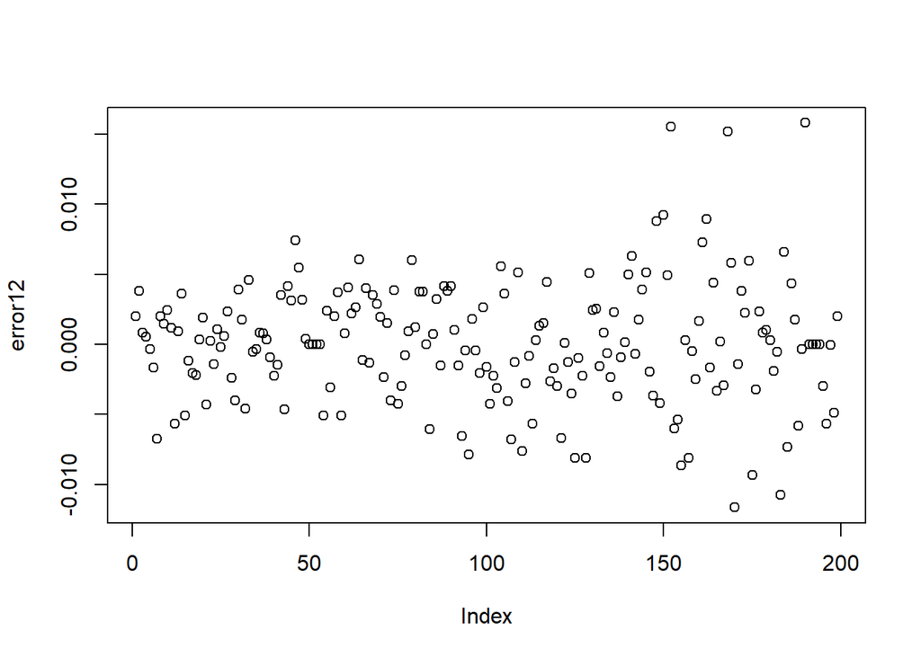

```r
error12<-residuals(var4$varresult$DINPPD)
plot(error12)
```

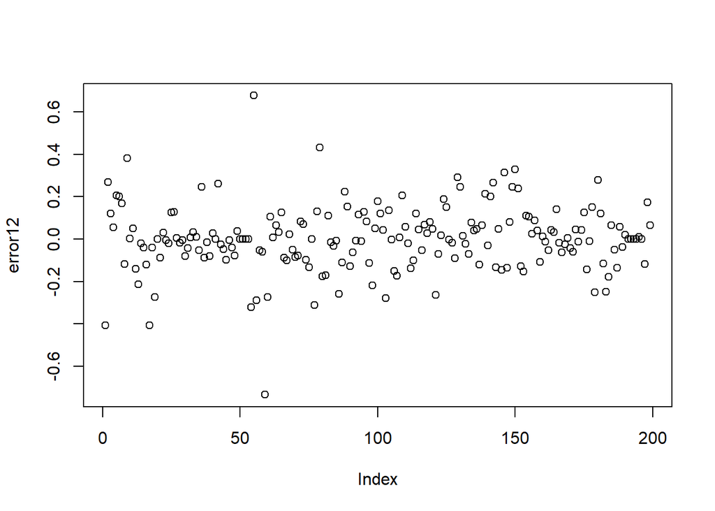

```r
error12<-residuals(var4$varresult$DifCETES)
plot(error12)
```

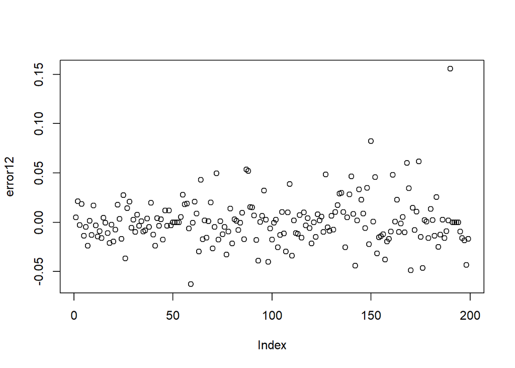

```r
error12<-residuals(var4$varresult$DFIXD)
plot(error12)
```

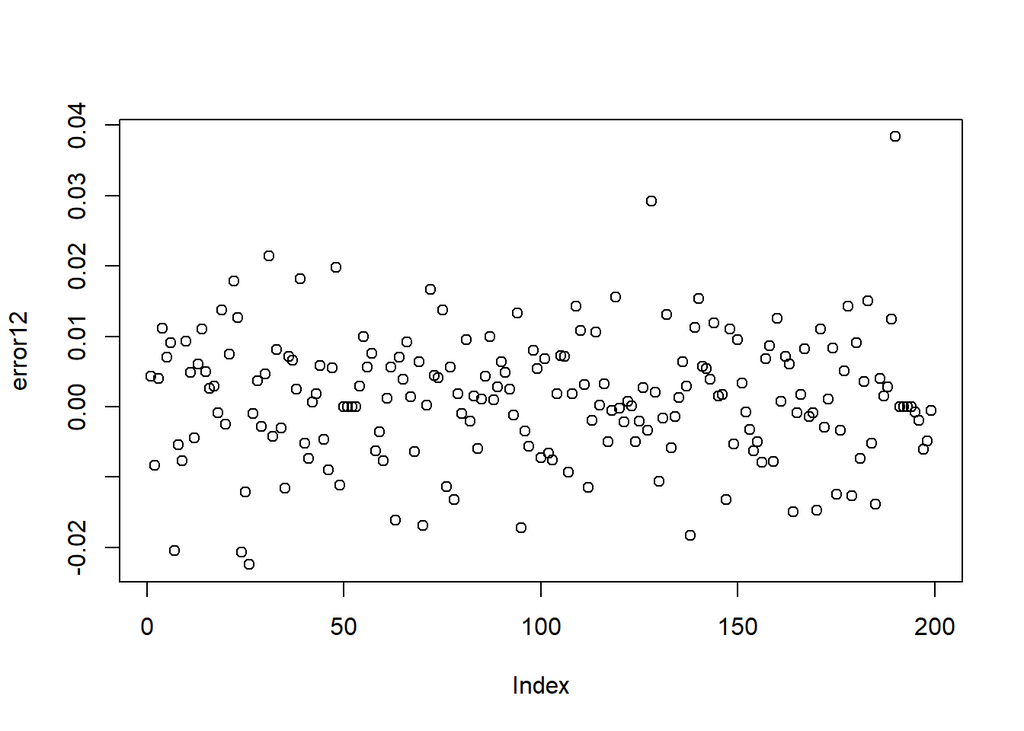

```r
error12<-residuals(var4$varresult$DLM2D)
plot(error12)
```

```r
summary(var4, equation= "DFIXD")
```

```
##
## VAR Estimation Results:
## =========================
## Endogenous variables: DFIXD, DINPPD, DLM2D, DifCETES, d08s, d20s
## Deterministic variables: none
## Sample size: 199
## Log Likelihood: 2593.916
## Roots of the characteristic polynomial:
## 0.9269 0.8044 0.7765 0.7765 0.728 0.728 0.7123 0.7123 0.6936 0.6936 0.6779 0.6779 0.6752 0.6752 0.6553 0.6553 0.6148 0.6148 0.5133 0.5133 0.4801 0.4801 0.2678 0.1386
## Call:
## vars::VAR(y = Datos, p = 4, type = "none")
##
##
## Estimation results for equation DFIXD:
## ======================================
## DFIXD = DFIXD.l1 + DINPPD.l1 + DLM2D.l1 + DifCETES.l1 + d08s.l1 + d20s.l1 + DFIXD.l2 + DINPPD.l2 + DLM2D.l2 + DifCETES.l2 + d08s.l2 + d20s.l2 + DFIXD.l3 + DINPPD.l3 + DLM2D.l3 + DifCETES.l3 + d08s.l3 + d20s.l3 + DFIXD.l4 + DINPPD.l4 + DLM2D.l4 + DifCETES.l4 + d08s.l4 + d20s.l4
##
##              Estimate Std. Error t value Pr(>|t|)
## DFIXD.l1     0.237056   0.092370   2.566   0.0111 *
## DINPPD.l1   -1.112541   0.490834  -2.267   0.0246 *
## DLM2D.l1     0.456682   0.224746   2.032   0.0437 *
## DifCETES.l1  0.004890   0.010989   0.445   0.6569
## d08s.l1     -0.002222   0.026553  -0.084   0.9334
## d20s.l1      0.031625   0.029396   1.076   0.2835
## DFIXD.l2    -0.054648   0.095635  -0.571   0.5684
## DINPPD.l2   -0.878614   0.532805  -1.649   0.1009
## DLM2D.l2     0.337944   0.223030   1.515   0.1315
## DifCETES.l2  0.013547   0.010332   1.311   0.1915
## d08s.l2     -0.005406   0.026655  -0.203   0.8395
## d20s.l2     -0.043640   0.030058  -1.452   0.1483
## DFIXD.l3    -0.037809   0.094542  -0.400   0.6897
## DINPPD.l3   -0.096211   0.517629  -0.186   0.8528
## DLM2D.l3     0.421179   0.225005   1.872   0.0629 .
## DifCETES.l3  0.001046   0.010127   0.103   0.9178
## d08s.l3      0.051717   0.027457   1.884   0.0613 .
## d20s.l3     -0.034017   0.030352  -1.121   0.2639
## DFIXD.l4     0.018903   0.084903   0.223   0.8241
## DINPPD.l4    0.027300   0.462255   0.059   0.9530
## DLM2D.l4    -0.076511   0.240411  -0.318   0.7507
## DifCETES.l4 -0.014286   0.009805  -1.457   0.1469
```

[output cut: 14 more lines]

```
## DFIXD     6.565e-04 6.225e-05  9.868e-05  8.480e-04 -1.708e-05  8.879e-04
## DINPPD    6.225e-05 2.100e-05  9.344e-06  1.002e-04  2.650e-06  9.015e-05
## DLM2D     9.868e-05 9.344e-06  8.854e-05 -3.795e-05 -5.968e-05  2.169e-04
## DifCETES  8.480e-04 1.002e-04 -3.795e-05  2.739e-02  2.197e-04  1.134e-04
## d08s     -1.708e-05 2.650e-06 -5.968e-05  2.197e-04  5.243e-03 -9.550e-05
## d20s      8.879e-04 9.015e-05  2.169e-04  1.134e-04 -9.550e-05  5.433e-03
##
## Correlation matrix of residuals:
##              DFIXD   DINPPD    DLM2D  DifCETES      d08s      d20s
## DFIXD     1.000000 0.530154  0.40929  0.199971 -0.009208  0.470143
## DINPPD    0.530154 1.000000  0.21670  0.132096  0.007987  0.266881
## DLM2D     0.409289 0.216696  1.00000 -0.024370 -0.087592  0.312761
## DifCETES  0.199971 0.132096 -0.02437  1.000000  0.018336  0.009294
## d08s     -0.009208 0.007987 -0.08759  0.018336  1.000000 -0.017894
## d20s      0.470143 0.266881  0.31276  0.009294 -0.017894  1.000000
```

```r
vars::normality.test(var4, multivariate.only = TRUE)
```

```
## $JB
##
##  JB-Test (multivariate)
##
## data:  Residuals of VAR object var4
## Chi-squared = 313293, df = 12, p-value < 2.2e-16
##
##
## $Skewness
##
##  Skewness only (multivariate)
##
## data:  Residuals of VAR object var4
## Chi-squared = 7571.1, df = 6, p-value < 2.2e-16
##
##
## $Kurtosis
##
##  Kurtosis only (multivariate)
##
## data:  Residuals of VAR object var4
## Chi-squared = 305722, df = 6, p-value < 2.2e-16
```

```r
serial.test(var4, lags.bg = 1, type = "BG")
```

```
##
##  Breusch-Godfrey LM test
##
## data:  Residuals of VAR object var4
## Chi-squared = 41.719, df = 36, p-value = 0.2361
```

```r
serial.test(var4, lags.bg = 2, type = "BG")
```

```
##
##  Breusch-Godfrey LM test
##
## data:  Residuals of VAR object var4
## Chi-squared = 85.873, df = 72, p-value = 0.1263
```

```r
serial.test(var4, lags.bg = 3, type = "BG")
```

```
##
##  Breusch-Godfrey LM test
##
## data:  Residuals of VAR object var4
## Chi-squared = 132.98, df = 108, p-value = 0.05168
```

```r
serial.test(var4, lags.bg = 4, type = "BG")
```

```
##
##  Breusch-Godfrey LM test
##
## data:  Residuals of VAR object var4
## Chi-squared = 163.44, df = 144, p-value = 0.1278
```

```r
arch.test(var4, lags.multi = 4)
```

```
##
##  ARCH (multivariate)
##
## data:  Residuals of VAR object var4
## Chi-squared = 1813.6, df = 1764, p-value = 0.201
```

El modelo pasa la prueba de estabilidad porque sus coeficientes son menores a 1. No presenta autocorrelación de cuarto orden o inferior como demuestra la prueba Breusch-Godfrey. Tampoco presenta heteroscedasticidad como demuestra la prueba ARCH. Sin embargo, reconocemos que el modelo no presenta normalidad. Se intentó corregir con variables dicotómicas (dummys), cambianod la periodicidad de los datos e insertando una matriz de dummys. Con ninguna propuesta se corrigió la no normalidad. Para fines académicos supondremos que el modelo presenta normalidad.

###Resultados y grÃ¡ficas de impulso-respuesta.

Una vez validado que nuestra propuesta de modelo VAR cumple con los supuestos de correcta especificación, se realizaron una gráficas de impulso-respuesta enfocadas en el tipo de cambio. Se realizó para 12 periodos que corresponden a los 12 meses que componen un año.

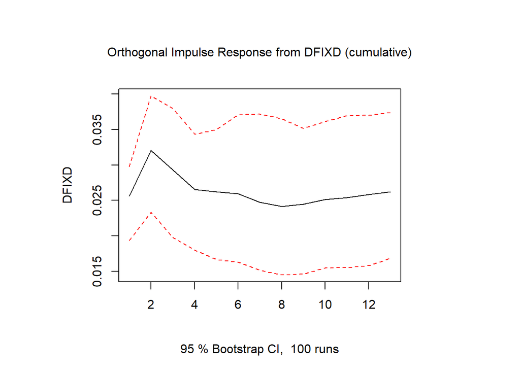

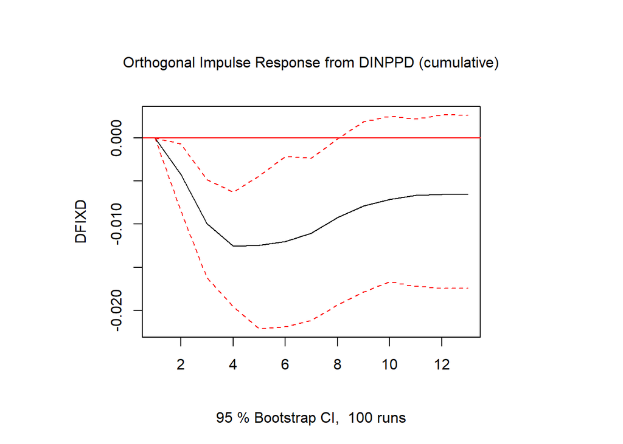

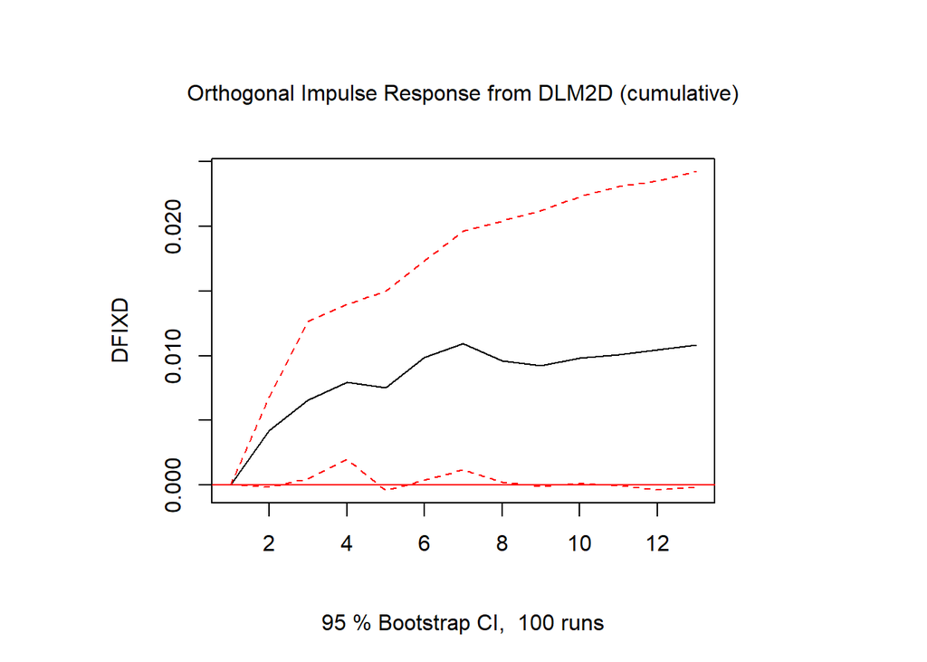

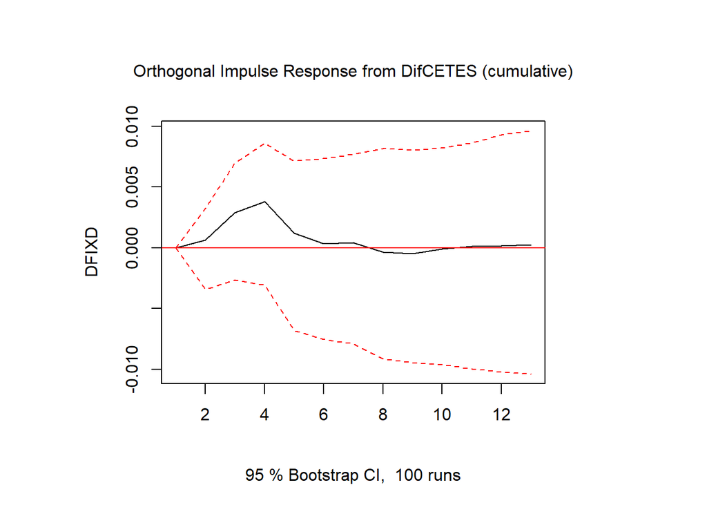

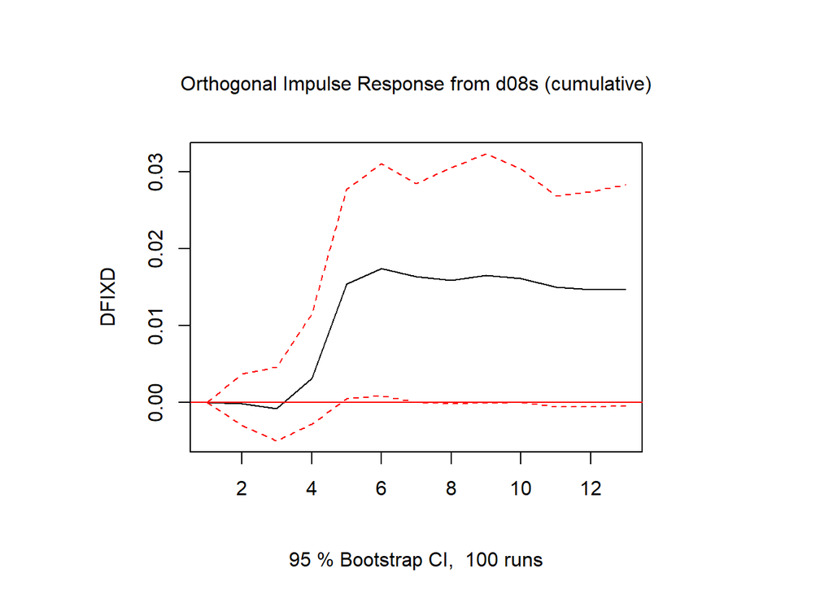

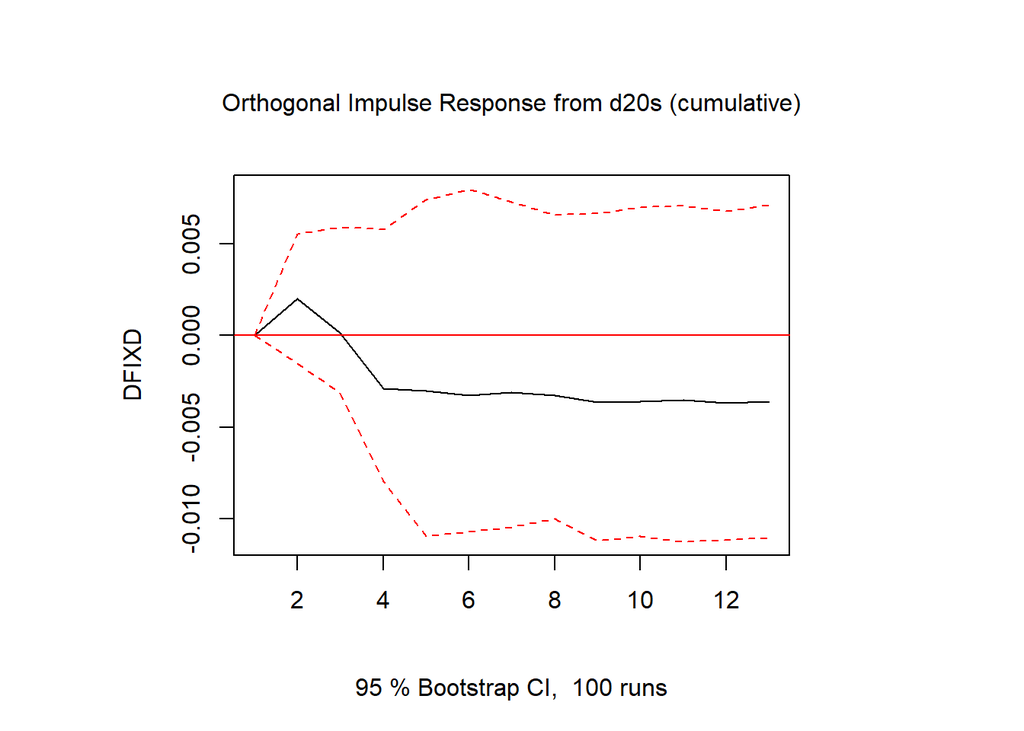

```r
IR_FIX <- irf(var4, n.ahead = 12, boot = TRUE,
              ci = 0.95, response = "DFIXD", ortho = TRUE, cumulative = TRUE)

plot(IR_FIX)
```

La tasa de los Cetes a 28 días no tiene un impacto significativo en el tipo de cambio. En nuestras iteraciones, descubirmos que las variables omitidas en este modelo (Precio del petroleo y brecha del producto) tampoco tuvieron un efecto significativo en el análisis impulso-respuesta.

Las variables dummy carecen de interpretaciÃ³n al ser variables meramente instrumentales.

## **Referencias**

- CASTILLO PONCE, Ramón A. y HERRERA HERNÁNDEZ, Jorge, (2005) âFactores determinantes del tipo de cambio peso-dólar durante el periodo de libre flotaciónâ, Comercio Exterior, vol. 55, núm. 11, noviembre, México. ENGEL, Charles, (2000) âOptimal exchange rate policy: the influence of price setting an asset marketsâ, National Bureau of Economic Research (NBER), Working Paper, núm.7889
- ITO, Takatoshi, SASAKI, Yuri N. y SATO, Kiyotaka, (2005)âPass-Through of Exchange Rate Changes and Macroeconomic Shocks to Domestic Inflation in East Asian Countriesâ, RIETI Discussion Papers Series, 05-E-020, abril, pp. 2-55.
- LEÓN LEÓN, Josefina, (2008) âLa mano invisible del mercado y la evolución de las políticas monetaria y cambiaria: México, 1995-2005â, Análisis Económico, núm. 53, vo1. XXIII, Segundo cuatrimestre, pp. 111-142.
- MACÍAS MACÍAS, Alejandro, (2003) âTipo de cambio y paridad del poder de compra en Méxicoâ, Comercio Exterior, vol. 53, núm. 9, septiembre, México, pp. 820-831.
- MENDOZA, Enrique, (2000) âOn the Instability of Variance Decompositions of the Real Exchange Rate Across Exchange-Rate Regimes: Evidence from Mexico and the United Statesâ, National Bureau of Economic Research (NBER) Working Paper, nÃºm.7768.
- MORALES, A., e HIGUERA, R., (2007), âEl tipo de cambio y las inversiones en la globalización financiera, el caso de México: Determinantes del tipo de cambio 1986-2000â en Quinto Encuentro Internacional sobre Globalización Financiera.
- NAVARRO, J., y SANTOS Y., (2007), âDeterminación econométrica del tipo de cambio nominal en Méxicoâ en Revista Nicolaita de Estudios Económicos vol 2, núm. 1, enero - junio, pp. 9-27.
- RIVAS B, M., (2018), âAnálisis de los determinantes del tipo de cambio y ciclos comunes entre México y Estados Unidos durante 1994 a 2017â. Tesis de Maestría Economía Aplicada. El Colegio de la Frontera Norte, A.C. México. 100 pp.
- WERNER, Alejandro M., (1997a) âUn estudio estadístico sobre el comportamiento de la cotización del peso mexicano frente al dólar y su volatilidadâ, Documento de Investigación, Banco de México, núm. 9701.
- WERNER, Alejandro M. y BAZDRESCH, Santiago, (2002) âEl comportamiento del tipo de cambio en México y el régimen de libre flotación: 1996â“2001â, Documento de Investigación, Banco de México.
- WIJNBERGEN, S., (1990), âCrecimiento, deuda externa y tipo de cambio real en Méxicoâ en El Trimestre Económico. Vol. 57, No. 227(3) (Julio-Septiembre), pp. 755-792.